# Diss cleaning

```r
# Get the number and percentage of participants who chose
# each researcher for each attribute and vignette

attribute_descriptives = attr_model_dat %>%
  group_by(vignette_id, severity_num, attribute, researcher_ec) %>%
  summarise(
    N = sum(chosen == 1, na.rm = TRUE),
    .groups = "drop"
  ) %>%
  group_by(vignette_id, severity_num, attribute) %>%
  mutate(
    Total_N = sum(N),
    Percent = round(N / Total_N * 100, 2)
  ) %>%
  tidyr::pivot_wider(
    names_from = researcher_ec,
    values_from = c(N, Percent),
    values_fill = 0,
    names_glue = "{.value}_{researcher_ec}"
  ) %>%
  rename(
    Investigator_N = `N_-1`,
    Inspector_N = `N_1`,
    Investigator_Percent = `Percent_-1`,
    Inspector_Percent = `Percent_1`
  ) %>%
  ungroup()

print(attribute_descriptives, n = 27)
```

```
## # A tibble: 27 × 8
##    vignette_id severity_num attribute Total_N
##    <fct>              <dbl> <fct>       <int>
##  1 minor                  0 smarter       248
##  2 minor                  0 better_r…     337
##  3 minor                  0 creative      255
##  4 minor                  0 rather_be     340
##  5 minor                  0 should_be     346
##  6 minor                  0 celebrat…     362
##  7 minor                  0 typical       358
##  8 minor                  0 job_secu…     365
##  9 minor                  0 job_outc…     367
## 10 moderate               1 smarter       269
## 11 moderate               1 better_r…     361
## 12 moderate               1 creative      253
```

[output cut: 19 more lines]

```r
### 5. Overall attribute test + pairwise comparisons

# Test the overall effect of attribute

anova(A4, test = "Chisq")
```

```
## Analysis of Variance Table
##                            npar Sum Sq
## researcher_ec                 1 4701.0
## severity_num                  1    7.5
## attribute                     8  354.3
## researcher_ec:severity_num    1  440.2
##                            Mean Sq   F value
## researcher_ec               4701.0 4701.0437
## severity_num                   7.5    7.4704
## attribute                     44.3   44.2840
## researcher_ec:severity_num   440.2  440.1502
```

```r
# Get estimated marginal means for each attribute

library(emmeans)
attribute_emmeans = emmeans(
  A4,
  ~ attribute,
  type = "response"
)

print(attribute_emmeans)
```

```
##  attribute          prob      SE  df
##  smarter           0.220 0.01050 Inf
##  better_researcher 0.338 0.01330 Inf
##  creative          0.196 0.00973 Inf
##  rather_be         0.330 0.01310 Inf
##  should_be         0.356 0.01360 Inf
##  celebrated        0.367 0.01370 Inf
##  typical           0.313 0.01280 Inf
##  job_security      0.386 0.01400 Inf
##  job_outcome       0.377 0.01390 Inf
##  asymp.LCL asymp.UCL
##      0.201     0.242
##      0.312     0.364
##      0.177     0.216
##      0.305     0.357
##      0.330     0.383
##      0.341     0.394
##      0.289     0.339
##      0.359     0.414
##      0.350     0.405
##
## Results are averaged over the levels of: researcher_ec
## Confidence level used: 0.95
## Intervals are back-transformed from the logit scale
```

```r
# Compare attributes to each other

pairs(
  attribute_emmeans,
  adjust = "bonferroni"
)
```

```
##  contrast                         odds.ratio
##  smarter / better_researcher           0.554
##  smarter / creative                    1.161
##  smarter / rather_be                   0.573
##  smarter / should_be                   0.511
##  smarter / celebrated                  0.487
##  smarter / typical                     0.621
##  smarter / job_security                0.450
##  smarter / job_outcome                 0.467
##  better_researcher / creative          2.096
##  better_researcher / rather_be         1.034
##  better_researcher / should_be         0.922
##  better_researcher / celebrated        0.880
##  better_researcher / typical           1.120
##  better_researcher / job_security      0.812
##  better_researcher / job_outcome       0.843
##  creative / rather_be                  0.494
##  creative / should_be                  0.440
##  creative / celebrated                 0.420
##  creative / typical                    0.534
##  creative / job_security               0.387
##  creative / job_outcome                0.402
##  rather_be / should_be                 0.891
##  rather_be / celebrated                0.850
##  rather_be / typical                   1.083
##  rather_be / job_security              0.785
##  rather_be / job_outcome               0.815
##  should_be / celebrated                0.954
##  should_be / typical                   1.215
##  should_be / job_security              0.880
##  should_be / job_outcome               0.914
##  celebrated / typical                  1.273
##  celebrated / job_security             0.923
##  celebrated / job_outcome              0.958
##  typical / job_security                0.725
##  typical / job_outcome                 0.753
##  job_security / job_outcome            1.039
##      SE  df null z.ratio p.value
##  0.0378 Inf    1  -8.654 <0.0001
##  0.0809 Inf    1   2.146  1.0000
```

[output cut: 23 more lines]

```
##  0.0545 Inf    1  -3.058  0.0802
##  0.0637 Inf    1  -0.705  1.0000
##  0.0814 Inf    1   2.899  0.1347
##  0.0587 Inf    1  -1.911  1.0000
##  0.0610 Inf    1  -1.342  1.0000
##  0.0853 Inf    1   3.603  0.0113
##  0.0615 Inf    1  -1.207  1.0000
##  0.0639 Inf    1  -0.637  1.0000
##  0.0485 Inf    1  -4.806 <0.0001
##  0.0504 Inf    1  -4.239  0.0008
##  0.0692 Inf    1   0.569  1.0000
##
## Results are averaged over the levels of: researcher_ec
## P value adjustment: bonferroni method for 36 tests
## Tests are performed on the log odds ratio scale
```

###table

```r
# Create APA-style table of researcher choices by attribute and severity

attribute_table = attribute_descriptives %>%
  mutate(
    Investigator = paste0(
      Investigator_N, " (", Investigator_Percent, "%)"
    ),
    Inspector = paste0(
      Inspector_N, " (", Inspector_Percent, "%)"
    )
  ) %>%
  select(
    severity = vignette_id,
    attribute,
    Investigator,
    Inspector
  ) %>%
  tidyr::pivot_wider(
    names_from = severity,
    values_from = c(Investigator, Inspector)
  ) %>%
  select(
    attribute,
    Investigator_minor,
    Inspector_minor,
    Investigator_moderate,
    Inspector_moderate,
    Investigator_major,
    Inspector_major
  )

knitr::kable(
  attribute_table,
  caption = "Researcher Selections for Positive Attributes by QRP Severity",
  col.names = c(
    "Attribute",
    "Investigator",
    "Inspector",
    "Investigator",
    "Inspector",
    "Investigator",
    "Inspector"
  ),
  align = c("l", "c", "c", "c", "c", "c", "c")
)
```

Researcher Selections for Positive Attributes by QRP Severity

| Attribute | Investigator | Inspector | Investigator | Inspector | Investigator | Inspector |
| --- | --- | --- | --- | --- | --- | --- |
| smarter | 59 (23.79%) | 189 (76.21%) | 31 (11.52%) | 238 (88.48%) | 16 (5.33%) | 284 (94.67%) |
| better_researcher | 48 (14.24%) | 289 (85.76%) | 25 (6.93%) | 336 (93.07%) | 13 (3.49%) | 360 (96.51%) |
| creative | 144 (56.47%) | 111 (43.53%) | 146 (57.71%) | 107 (42.29%) | 124 (50%) | 124 (50%) |
| rather_be | 70 (20.59%) | 270 (79.41%) | 20 (5.6%) | 337 (94.4%) | 15 (4.18%) | 344 (95.82%) |
| should_be | 42 (12.14%) | 304 (87.86%) | 11 (2.89%) | 369 (97.11%) | 11 (2.89%) | 370 (97.11%) |
| celebrated | 82 (22.65%) | 280 (77.35%) | 43 (11.11%) | 344 (88.89%) | 27 (7.12%) | 352 (92.88%) |
| typical | 213 (59.5%) | 145 (40.5%) | 146 (42.94%) | 194 (57.06%) | 112 (34.67%) | 211 (65.33%) |
| job_security | 69 (18.9%) | 296 (81.1%) | 31 (7.75%) | 369 (92.25%) | 19 (4.76%) | 380 (95.24%) |
| job_outcome | 107 (29.16%) | 260 (70.84%) | 55 (14.25%) | 331 (85.75%) | 34 (8.63%) | 360 (91.37%) |

# Integrity & LIKEABILITY ANALYSIS (RQ1, RQ2) + TRUENESS (RQ3)

Research Question 1: How is integrity influenced by role and QRP severity? • Hypothesis 1a: Inspectors will be rated higher in integrity than investigators. • Hypothesis 1b: The relative integrity of inspectors versus investigators will increase as QRP severity increases.

Research Question 2: How is likeability influenced by role and QRP severity? • Hypothesis 2a: Investigators will be rated more likable than inspectors. • Hypothesis 2b: At low QRP severity, investigators will be rated as more likeable than inspectors, but at high QRP severity, inspectors will be rated as more likeable than investigators.

Research Question 3: Is the perceived trueness of the finding influenced by QRP severity? • Hypothesis 3: Perceived trueness will decrease as QRP severity increases.

Research Questions 1–2: Integrity and Likeability Step-up MLMs will test Role, Severity, and Role × Severity interaction:

Model 1: Integrity/Likeabilityijk = γ000 + γ100 (Researcherj) + ν0k + μ0jk + εijk Model 2: Integrity/Likeabilityijk = γ000 + γ010 (Severityk) + ν0k + μ0k + εijk Model 3: Integrity/Likeabilityijk = γ000 + γ100 (Researcherj) + γ010 (Severityk) + ν0k + μ0jk + εijk Model 4: Integrity/Likeabilityijk = γ000 + γ100 (Researcherj) + γ010 (Severityk) + γ110(Researcherj × Severityk) + ν0k + μ0jk + εijk

Research Question 3: Trueness of Findings Model FT1: Truenessijk= γ000 + γ010 (Severityk) + ν0k + μ0j + εijk

## Build dataset

```r
# Vignette metadata
# Each vignette pair: investigator (inv) and inspector (insp)
# Severity:minor = vignette K/S, moderate = H/F, major = X/Y
# Integrity items: hon, sin, eth  (honest, sincere, ethical)
# Likeability: like, app (likeable, approachable)
# Trueness (conf): investigator only, 1 item per vignette

vignette_map = list(
  list(vig_letter = "k", vig_id = "minor",    role = "investigator",
       hon = "khon", sin = "ksin",  eth = "keth",
       like = "klike",  app = "kapp",  conf = "kcon"),
  list(vig_letter = "s", vig_id = "minor",    role = "inspector",
       hon = "shon",    sin = "ssin",  eth = "seth",
       like = "slike",  app = "sapp",  conf = NA),
  list(vig_letter = "h", vig_id = "moderate", role = "investigator",
       hon = "hhon",    sin = "hsin",  eth = "heth",
       like = "hlike",  app = "happ",  conf = "hcon"),
  list(vig_letter = "f", vig_id = "moderate", role = "inspector",
       hon = "fhon",    sin = "fsin",  eth = "feth",
       like = "flike",  app = "fapp",  conf = NA),
  list(vig_letter = "x", vig_id = "major",    role = "investigator",
       hon = "xhon",   sin = "xsin",  eth = "xeth",
       like = "xlike",  app = "xapp",  conf = "xcon"),
  list(vig_letter = "y", vig_id = "major",    role = "inspector",
       hon = "yhon",    sin = "ysin",  eth = "yeth",
       like = "ylike",  app = "yapp",  conf = NA)
)
# vig_letter is the TRUE vignette identifier (6 distinct narrative vignettes:
# k/s/h/f/x/y). vig_id (severity) is NOT a valid vignette-level random effect
# on its own — it only has 3 levels and is perfectly confounded with
# severity_num, the key fixed effect. vig_letter fixes this: it captures
# idiosyncratic vignette-writing variance independent of role and severity.

#Helper: extract numeric value from labelled string
parse_num = function(x) as.numeric(str_extract(as.character(x), "^\\d"))

#Build one row per participant × vignette × role
tl_rows = bind_rows(lapply(vignette_map, function(v) {
  filtered_by_age %>%                          # use cleaned dataset
    transmute(
      responseid,
      vig_letter = v$vig_letter,
      vig_id   = v$vig_id,
      role     = v$role,
      hon_raw  = parse_num(.data[[v$hon]]),
      sin_raw  = parse_num(.data[[v$sin]]),
      eth_raw  = parse_num(.data[[v$eth]]),
      like_raw = parse_num(.data[[v$like]]),
      app_raw  = parse_num(.data[[v$app]]),
      conf_raw = if (!is.na(v$conf)) parse_num(.data[[v$conf]]) else NA_real_
    )
}))

#Composites & factors
tl_dat = tl_rows %>%
  mutate(
    Integrity      = rowMeans(cbind(hon_raw, sin_raw, eth_raw), na.rm = TRUE),
    likeability = rowMeans(cbind(like_raw, app_raw), na.rm = TRUE),
    severity   = factor(vig_id,   levels = c("minor", "moderate", "major")),
    role       = factor(role,     levels = c("investigator", "inspector")),
    responseid = factor(responseid),
    vignette_id = factor(vig_letter, levels = c("k","s","h","f","x","y")),
    # effect-coded predictors
    role_ec    = if_else(role == "inspector", 1, -1),
    severity_num = case_when(
      severity == "minor" ~ 0,
      severity == "moderate" ~ 1,
      severity == "major" ~ 2
    )
  )

glimpse(tl_dat)
```

```
## Rows: 2,730
## Columns: 16
## $ responseid   <fct> R_1kWnphloUO7A7Tj, R_5…
## $ vig_letter   <chr> "k", "k", "k", "k", "k…
## $ vig_id       <chr> "minor", "minor", "min…
## $ role         <fct> investigator, investig…
## $ hon_raw      <dbl> 3, 5, 2, 4, 3, 2, 3, 2…
## $ sin_raw      <dbl> 2, 5, 2, 4, 2, 4, 4, 2…
## $ eth_raw      <dbl> 1, 5, 3, 2, 4, 4, 2, 2…
## $ like_raw     <dbl> 3, 3, 3, 3, 3, 3, 3, 3…
## $ app_raw      <dbl> 2, 4, 3, 5, 3, 4, 4, 4…
## $ conf_raw     <dbl> 3, 3, 3, 4, 4, 3, 3, 3…
## $ Integrity    <dbl> 2.000000, 5.000000, 2.…
## $ likeability  <dbl> 2.5, 3.5, 3.0, 4.0, 3.…
## $ severity     <fct> minor, minor, minor, m…
## $ vignette_id  <fct> k, k, k, k, k, k, k, k…
## $ role_ec      <dbl> -1, -1, -1, -1, -1, -1…
## $ severity_num <dbl> 0, 0, 0, 0, 0, 0, 0, 0…
```

Check structure and counts

```r
table(tl_dat$role, tl_dat$severity)
```

```
##
##                minor moderate major
##   investigator   455      455   455
##   inspector      455      455   455
```

```r
# Quick descriptives
tl_dat %>%
  group_by(role, severity) %>%
  summarise(
    n          = sum(!is.na(Integrity)),
    Integrity_M    = round(mean(Integrity, na.rm = TRUE), 2),
    Integrity_SD   = round(sd(Integrity,   na.rm = TRUE), 2),
    like_M     = round(mean(likeability, na.rm = TRUE), 2),
    like_SD    = round(sd(likeability,   na.rm = TRUE), 2),
    .groups = "drop"
  ) %>%
  kable(caption = "Descriptives: Integrity & Likeability by Role × Severity") %>%
  style_table()
```

Descriptives: Integrity & Likeability by Role × Severity

| role | severity | n | Integrity_M | Integrity_SD | like_M | like_SD |
| --- | --- | --- | --- | --- | --- | --- |
| investigator | minor | 446 | 2.79 | 0.86 | 3.03 | 0.77 |
| investigator | moderate | 447 | 1.69 | 0.73 | 2.36 | 0.81 |
| investigator | major | 447 | 1.39 | 0.70 | 2.02 | 0.84 |
| inspector | minor | 445 | 4.17 | 0.83 | 3.59 | 0.94 |
| inspector | moderate | 447 | 4.35 | 0.73 | 3.87 | 0.86 |
| inspector | major | 446 | 4.40 | 0.73 | 3.94 | 0.86 |

##Reliability & validation checks

```r
library(psych)

#Integrity alpha per role × severity (using the 3 items)
Integrity_items_inv = filtered_by_age %>%
  transmute(
    min_hon = parse_num(khon), min_sin = parse_num(ksin),   min_eth = parse_num(keth),
    mod_hon = parse_num(hhon),    mod_sin = parse_num(hsin),   mod_eth = parse_num(heth),
    maj_hon = parse_num(xhon),   maj_sin = parse_num(xsin),   maj_eth = parse_num(xeth)
  )

Integrity_items_insp = filtered_by_age %>%
  transmute(
    min_hon = parse_num(shon),  min_sin = parse_num(ssin),  min_eth = parse_num(seth),
    mod_hon = parse_num(fhon),  mod_sin = parse_num(fsin),  mod_eth = parse_num(feth),
    maj_hon = parse_num(yhon),  maj_sin = parse_num(ysin),  maj_eth = parse_num(yeth)
  )

psych::alpha(Integrity_items_inv,  check.keys = TRUE)$total %>% select(raw_alpha, std.alpha) %>% print()
```

```
##  raw_alpha std.alpha
##  0.7740442 0.7812991
```

```r
psych::alpha(Integrity_items_insp, check.keys = TRUE)$total %>% select(raw_alpha, std.alpha) %>% print()
```

```
##  raw_alpha std.alpha
##  0.8659431 0.8674587
```

```r
#Likeability alpha
like_items_inv = filtered_by_age %>%
  transmute(
    min_like = parse_num(klike), min_app = parse_num(kapp),
    mod_like = parse_num(hlike), mod_app = parse_num(happ),
    maj_like = parse_num(xlike), maj_app = parse_num(xapp)
  )

like_items_insp = filtered_by_age %>%
  transmute(
    min_like = parse_num(slike), min_app = parse_num(sapp),
    mod_like = parse_num(flike), mod_app = parse_num(fapp),
    maj_like = parse_num(ylike), maj_app = parse_num(yapp)
  )

psych::alpha(like_items_inv,  check.keys = TRUE)$total %>% select(raw_alpha, std.alpha) %>% print()
```

```
##  raw_alpha std.alpha
##  0.7502138 0.7481344
```

```r
psych::alpha(like_items_insp, check.keys = TRUE)$total %>% select(raw_alpha, std.alpha) %>% print()
```

```
##  raw_alpha std.alpha
##  0.8304724  0.830882
```

```r
#Inter-composite correlation
cor.test(tl_dat$Integrity, tl_dat$likeability, use = "complete.obs") %>% tidy() %>% print()
```

```
## # A tibble: 1 × 8
##   estimate statistic p.value parameter
##      <dbl>     <dbl>   <dbl>     <int>
## 1    0.803      69.8       0      2676
## # ℹ 4 more variables: conf.low <dbl>,
## #   conf.high <dbl>, method <chr>,
## #   alternative <chr>
```

##Model-building strategy

### Model sequence for Integrity and Likeability

- Model 0: Null model
- Model 1: Role
- Model 2: QRP Severity
- Model 3: Role + QRP Severity
- Model 4: Role × QRP Severity

Model 1 tests the main effect of researcher role, corresponding to H1a for Integrity and H2a for Likeability. Model 4 tests the Role × QRP Severity interaction, corresponding to H1b and H2b.

```r
library(lme4)
library(lmerTest)
library(emmeans)
library(knitr)
library(kableExtra)

# Extract fixed effects, including Satterthwaite df, t, and p.
get_fixed_effects = function(model) {
  cf = summary(model)$coefficients

  data.frame(
    Parameter = rownames(cf),
    b = cf[, "Estimate"],
    SE = cf[, "Std. Error"],
    df = cf[, "df"],
    t = cf[, "t value"],
    p = cf[, "Pr(>|t|)"],
    row.names = NULL,
    check.names = FALSE
  )
}

# APA-friendly p-value formatting.
fmt_p = function(p) {
  if (is.na(p)) return("")
  if (p < .001) return("< .001")
  formatC(p, digits = 3, format = "f")
}

# APA-friendly number formatting.
fmt_num = function(x, digits = 2) {
  if (length(x) == 0 || is.na(x)) return("")
  formatC(x, digits = digits, format = "f")
}

# Rename model terms for tables.
relabel_terms = function(x) {
  dplyr::recode(
    x,
    "(Intercept)" = "Intercept",
    "role_ec" = "Role",
    "severity_num" = "QRP Severity",
    "role_ec:severity_num" = "Role × QRP Severity",
    .default = x
  )
}

# Likelihood-ratio comparison of two nested ML models.
compare_models = function(previous, current) {
  lr = anova(previous, current)
  data.frame(
    Chisq = lr$Chisq[2],
    df = lr$Df[2],
    p = lr$`Pr(>Chisq)`[2]
  )
}

# Build a model-fit table. Each chi-square is the LR test against
# the immediately preceding model.
model_fit_table = function(models, names) {
  out = lapply(seq_along(models), function(i) {
    m = models[[i]]

    if (i == 1) {
      chisq = NA_real_
      df = NA_real_
      p = NA_real_
    } else {
      lr = compare_models(models[[i - 1]], m)
      chisq = lr$Chisq
      df = lr$df
      p = lr$p
    }

    data.frame(
      Model = names[i],
      AIC = AIC(m),
      BIC = BIC(m),
      logLik = as.numeric(logLik(m)),
      Chisq = chisq,
      df = df,
      p = p,
      check.names = FALSE
    )
  })

  dplyr::bind_rows(out) %>%
    mutate(
      AIC = round(AIC, 1),
      BIC = round(BIC, 1),
      logLik = round(logLik, 1),
      Chisq = ifelse(is.na(Chisq), "—", sprintf("%.2f", Chisq)),
      df = ifelse(is.na(df), "—", as.character(df)),
      p = ifelse(is.na(p), "—", vapply(p, fmt_p, character(1)))
    )
}

# Extract variance components.
get_variance_components = function(model) {
  vc = as.data.frame(VarCorr(model))
  vc %>%
    select(grp, vcov, sdcor) %>%
    mutate(
      Variance = round(vcov, 3),
      SD = round(sdcor, 3)
    ) %>%
    select(grp, Variance, SD)
}

# ICC for random-intercept components. Random slopes/covariances are not
# interpreted as simple ICC components here.
get_random_intercept_icc = function(model) {
  vc = as.data.frame(VarCorr(model))
  intercepts = vc %>%
    filter(is.na(var1) | var1 == "(Intercept)")

  residual = vc$vcov[vc$grp == "Residual"]
  total = sum(intercepts$vcov) + residual

  intercepts %>%
    mutate(ICC = round(vcov / total, 3)) %>%
    select(grp, ICC)
}
```

##Integrity

**Research Question 1: How is integrity influenced by role and QRP severity?**

**Hypothesis 1a:** Inspectors will be rated higher in integrity than investigators.

**Hypothesis 1b:** The relative integrity of inspectors versus investigators will increase as QRP severity increases.

###Random-effects structure for Integrity

```r
T4_max1 = lmer(
  Integrity ~ role_ec * severity_num +
    (1 + role_ec * severity_num | responseid),
  data = tl_dat,
  REML = FALSE,
  control = lmerControl(optimizer = "bobyqa")
)
```

```
## boundary (singular) fit: see help('isSingular')
```

```r
T4_max1_singular = isSingular(T4_max1, tol = 1e-4)
print(T4_max1_singular)
```

```
## [1] TRUE
```

```r
# Step down: remove random interaction slope

T4_max2 = lmer(
  Integrity ~ role_ec * severity_num +
    (1 + role_ec + severity_num | responseid),
  data = tl_dat,
  REML = FALSE,
  control = lmerControl(optimizer = "bobyqa")
)
```

```
## boundary (singular) fit: see help('isSingular')
```

```r
T4_max2_singular = isSingular(T4_max2, tol = 1e-4)
print(T4_max2_singular)
```

```
## [1] TRUE
```

```r
# Step down: retain random role slope only

T4_max3 = lmer(
  Integrity ~ role_ec * severity_num +
    (1 + role_ec | responseid),
  data = tl_dat,
  REML = FALSE,
  control = lmerControl(optimizer = "bobyqa")
)

T4_max3_singular = isSingular(T4_max3, tol = 1e-4)
print(T4_max3_singular)
```

```
## [1] FALSE
```

```r
# Test preregistered vignette random intercept with the winning

T4_prereg = lmer(
  Integrity ~ role_ec * severity_num +
    (1 + role_ec | responseid) +
    (1 | vignette_id),
  data = tl_dat,
  REML = FALSE,
  control = lmerControl(optimizer = "bobyqa")
)

T4_prereg_singular = isSingular(T4_prereg, tol = 1e-4)
print(T4_prereg_singular)
```

```
## [1] FALSE
```

```r
# Decision rule used throughout the analysis:
# retain the vignette intercept if the preregistered structure is
# non-singular; otherwise use the participant-only structure.
Integrity_uses_vignette_term = !T4_prereg_singular

cat(
  "Integrity final random-effects structure includes vignette intercept:",
  Integrity_uses_vignette_term,
  "\n"
)
```

```
## Integrity final random-effects structure includes vignette intercept: TRUE
```

###step-up models

```r
if (Integrity_uses_vignette_term) {

  random_part_Integrity = "vignette"

  M0_Integrity = lmer(
    Integrity ~ 1 +
      (1 + role_ec | responseid) +
      (1 | vignette_id),
    data = tl_dat,
    REML = FALSE,
    control = lmerControl(optimizer = "bobyqa")
  )

  T1 = lmer(
    Integrity ~ role_ec +
      (1 + role_ec | responseid) +
      (1 | vignette_id),
    data = tl_dat,
    REML = FALSE,
    control = lmerControl(optimizer = "bobyqa")
  )

  T2 = lmer(
    Integrity ~ severity_num +
      (1 + role_ec | responseid) +
      (1 | vignette_id),
    data = tl_dat,
    REML = FALSE,
    control = lmerControl(optimizer = "bobyqa")
  )

  T3 = lmer(
    Integrity ~ role_ec + severity_num +
      (1 + role_ec | responseid) +
      (1 | vignette_id),
    data = tl_dat,
    REML = FALSE,
    control = lmerControl(optimizer = "bobyqa")
  )

  T4 = T4_prereg

} else {

  random_part_Integrity = "participant_only"

  M0_Integrity = lmer(
    Integrity ~ 1 +
      (1 + role_ec | responseid),
    data = tl_dat,
    REML = FALSE,
    control = lmerControl(optimizer = "bobyqa")
  )

  T1 = lmer(
    Integrity ~ role_ec +
      (1 + role_ec | responseid),
    data = tl_dat,
    REML = FALSE,
    control = lmerControl(optimizer = "bobyqa")
  )

  T2 = lmer(
    Integrity ~ severity_num +
      (1 + role_ec | responseid),
    data = tl_dat,
    REML = FALSE,
    control = lmerControl(optimizer = "bobyqa")
  )

  T3 = lmer(
    Integrity ~ role_ec + severity_num +
      (1 + role_ec | responseid),
    data = tl_dat,
    REML = FALSE,
    control = lmerControl(optimizer = "bobyqa")
  )

  T4 = T4_max3
}


# Singularity checks for final models.
cat("Integrity final model singularity:\n")
```

```
## Integrity final model singularity:
```

```r
print(isSingular(M0_Integrity))
```

```
## [1] FALSE
```

```r
print(isSingular(T1))
```

```
## [1] FALSE
```

```r
print(isSingular(T2))
```

```
## [1] FALSE
```

```r
print(isSingular(T3))
```

```
## [1] FALSE
```

```r
print(isSingular(T4))
```

```
## [1] FALSE
```

```r
# Complete step-up comparison, including Model 0.
integrity_models = list(
  M0_Integrity,
  T1,
  T2,
  T3,
  T4
)

integrity_model_names = c(
  "Model 0: Null",
  "Model 1a: Role",
  "Model 1b: QRP Severity",
  "Model 1c: Role + QRP Severity",
  "Model 1d: Role × QRP Severity"
)

integrity_fit = model_fit_table(
  integrity_models,
  integrity_model_names
)

print(integrity_fit)
```

```
##                           Model    AIC
## 1                 Model 0: Null 5826.3
## 2                Model 1a: Role 5815.5
## 3        Model 1b: QRP Severity 5828.1
## 4 Model 1c: Role + QRP Severity 5815.3
## 5 Model 1d: Role × QRP Severity 5805.8
##      BIC  logLik Chisq df      p
## 1 5861.6 -2907.1     —  —      —
## 2 5856.7 -2900.7 12.80  1 < .001
## 3 5869.3 -2907.0  0.00  0      —
## 4 5862.5 -2899.7 14.72  1 < .001
## 5 5858.9 -2893.9 11.52  1 < .001
```

```r
# Full model summaries.
summary(T1)
```

```
## Linear mixed model fit by maximum
##   likelihood . t-tests use Satterthwaite's
##   method [lmerModLmerTest]
## Formula:
## Integrity ~ role_ec + (1 + role_ec | responseid) + (1 | vignette_id)
##    Data: tl_dat
## Control: lmerControl(optimizer = "bobyqa")
##
##       AIC       BIC    logLik -2*log(L)
##    5815.5    5856.7   -2900.7    5801.5
##  df.resid
##      2671
##
## Scaled residuals:
##     Min      1Q  Median      3Q     Max
## -4.9305 -0.5336  0.0050  0.4975  5.4349
##
## Random effects:
##  Groups      Name        Variance Std.Dev.
##  responseid  (Intercept) 0.0410   0.2025
##              role_ec     0.1679   0.4098
##  vignette_id (Intercept) 0.1850   0.4301
##  Residual                0.3755   0.6128
##  Corr
##
##  0.32
##
##
## Number of obs: 2678, groups:
## responseid, 448; vignette_id, 6
##
## Fixed effects:
##             Estimate Std. Error     df
## (Intercept)   3.1306     0.1762 6.0354
## role_ec       1.1764     0.1770 6.1461
##             t value Pr(>|t|)
## (Intercept)  17.764 1.93e-06 ***
## role_ec       6.645 0.000508 ***
## ---
## Signif. codes:
##   0 '***' 0.001 '**' 0.01 '*' 0.05 '.' 0.1  ' ' 1
##
## Correlation of Fixed Effects:
##         (Intr)
## role_ec 0.002
```

```r
summary(T2)
```

```
## Linear mixed model fit by maximum
##   likelihood . t-tests use Satterthwaite's
##   method [lmerModLmerTest]
## Formula:
## Integrity ~ severity_num + (1 + role_ec | responseid) + (1 |
##     vignette_id)
##    Data: tl_dat
## Control: lmerControl(optimizer = "bobyqa")
##
##       AIC       BIC    logLik -2*log(L)
##    5828.1    5869.3   -2907.0    5814.1
##  df.resid
##      2671
##
## Scaled residuals:
##     Min      1Q  Median      3Q     Max
## -4.9298 -0.5329  0.0068  0.4982  5.4377
##
## Random effects:
##  Groups      Name        Variance Std.Dev.
##  responseid  (Intercept) 0.0410   0.2025
##              role_ec     0.1679   0.4098
##  vignette_id (Intercept) 1.5090   1.2284
##  Residual                0.3755   0.6128
##  Corr
##
##  0.32
##
##
## Number of obs: 2678, groups:
## responseid, 448; vignette_id, 6
##
## Fixed effects:
##              Estimate Std. Error      df
## (Intercept)    3.4194     0.7932  5.9855
## severity_num  -0.2891     0.6144  5.9837
##              t value Pr(>|t|)
## (Intercept)    4.311  0.00506 **
## severity_num  -0.471  0.65462
## ---
## Signif. codes:
##   0 '***' 0.001 '**' 0.01 '*' 0.05 '.' 0.1  ' ' 1
##
## Correlation of Fixed Effects:
##             (Intr)
## severity_nm -0.775
```

```r
summary(T3)
```

```
## Linear mixed model fit by maximum
##   likelihood . t-tests use Satterthwaite's
##   method [lmerModLmerTest]
## Formula:
## Integrity ~ role_ec + severity_num + (1 + role_ec | responseid) +
##     (1 | vignette_id)
##    Data: tl_dat
## Control: lmerControl(optimizer = "bobyqa")
##
##       AIC       BIC    logLik -2*log(L)
##    5815.3    5862.5   -2899.7    5799.3
##  df.resid
##      2670
##
## Scaled residuals:
##     Min      1Q  Median      3Q     Max
## -4.9304 -0.5339  0.0084  0.5009  5.4362
##
## Random effects:
##  Groups      Name        Variance Std.Dev.
##  responseid  (Intercept) 0.0410   0.2025
##              role_ec     0.1679   0.4098
##  vignette_id (Intercept) 0.1292   0.3595
##  Residual                0.3755   0.6128
##  Corr
##
##  0.32
##
##
## Number of obs: 2678, groups:
## responseid, 448; vignette_id, 6
##
## Fixed effects:
##              Estimate Std. Error      df
## (Intercept)    3.4197     0.2330  6.0200
## role_ec        1.1764     0.1485  6.2090
## severity_num  -0.2891     0.1803  5.9996
##              t value Pr(>|t|)
## (Intercept)   14.676 6.11e-06 ***
## role_ec        7.921 0.000181 ***
## severity_num  -1.603 0.160024
## ---
## Signif. codes:
##   0 '***' 0.001 '**' 0.01 '*' 0.05 '.' 0.1  ' ' 1
##
## Correlation of Fixed Effects:
##             (Intr) role_c
## role_ec      0.002
## severity_nm -0.774  0.000
```

```r
summary(T4)
```

```
## Linear mixed model fit by maximum
##   likelihood . t-tests use Satterthwaite's
##   method [lmerModLmerTest]
## Formula:
## Integrity ~ role_ec * severity_num + (1 + role_ec | responseid) +
##     (1 | vignette_id)
##    Data: tl_dat
## Control: lmerControl(optimizer = "bobyqa")
##
##       AIC       BIC    logLik -2*log(L)
##    5805.8    5858.9   -2893.9    5787.8
##  df.resid
##      2669
##
## Scaled residuals:
##     Min      1Q  Median      3Q     Max
## -4.9277 -0.5336  0.0115  0.4970  5.4488
##
## Random effects:
##  Groups      Name        Variance Std.Dev.
##  responseid  (Intercept) 0.04098  0.2024
##              role_ec     0.16783  0.4097
##  vignette_id (Intercept) 0.01819  0.1349
##  Residual                0.37551  0.6128
##  Corr
##
##  0.32
##
##
## Number of obs: 2678, groups:
## responseid, 448; vignette_id, 6
##
## Fixed effects:
##                      Estimate Std. Error
## (Intercept)           3.41966    0.08957
## role_ec               0.76833    0.09114
## severity_num         -0.28909    0.06899
## role_ec:severity_num  0.40805    0.06899
##                            df t value
## (Intercept)           6.12808  38.177
## role_ec               6.56822   8.430
## severity_num          5.98856  -4.191
## role_ec:severity_num  5.98866   5.915
##                      Pr(>|t|)
## (Intercept)          1.60e-08 ***
## role_ec              9.31e-05 ***
## severity_num          0.00577 **
## role_ec:severity_num  0.00105 **
## ---
## Signif. codes:
##   0 '***' 0.001 '**' 0.01 '*' 0.05 '.' 0.1  ' ' 1
##
## Correlation of Fixed Effects:
##             (Intr) role_c svrty_
## role_ec      0.007
## severity_nm -0.770  0.000
## rl_c:svrty_  0.000 -0.757  0.000
```

###fixed effects and planned role contrasts

```r
# Fixed effects from every model, including Satterthwaite df, t, and p.
integrity_fixed_effects = lapply(
  integrity_models,
  get_fixed_effects
)

names(integrity_fixed_effects) = paste0("Model_", 0:4)

print(integrity_fixed_effects)
```

```
## $Model_0
##     Parameter        b        SE       df
## 1 (Intercept) 3.130303 0.5109205 5.989124
##         t           p
## 1 6.12679 0.000869963
##
## $Model_1
##     Parameter        b        SE       df
## 1 (Intercept) 3.130567 0.1762330 6.035409
## 2     role_ec 1.176382 0.1770359 6.146122
##           t            p
## 1 17.763798 1.933813e-06
## 2  6.644878 5.076228e-04
##
## $Model_2
##      Parameter          b        SE       df
## 1  (Intercept)  3.4193903 0.7932143 5.985468
## 2 severity_num -0.2890974 0.6143762 5.983710
##            t          p
## 1  4.3108027 0.00506125
## 2 -0.4705543 0.65462153
##
## $Model_3
##      Parameter          b        SE       df
## 1  (Intercept)  3.4196669 0.2330040 6.020004
## 2      role_ec  1.1763829 0.1485086 6.209048
## 3 severity_num -0.2890992 0.1803312 5.999621
##           t            p
## 1 14.676427 6.111727e-06
## 2  7.921310 1.809071e-04
## 3 -1.603157 1.600238e-01
##
## $Model_4
##              Parameter          b         SE
## 1          (Intercept)  3.4196595 0.08957405
## 2              role_ec  0.7683305 0.09114262
## 3         severity_num -0.2890927 0.06898501
## 4 role_ec:severity_num  0.4080529 0.06898531
##         df         t            p
## 1 6.128079 38.176899 1.602264e-08
## 2 6.568222  8.429981 9.307322e-05
## 3 5.988558 -4.190660 5.769306e-03
## 4 5.988660  5.915069 1.046404e-03
```

```r
# Planned comparison: inspectors versus investigators at each severity.
# Bonferroni correction is applied across the three severity-specific
# role comparisons.
emm_Integrity = emmeans(
  T4,
  ~ role_ec | severity_num,
  at = list(severity_num = c(0,1,2))
)

emm_Integrity_role = emmeans(
  T4,
  pairwise ~ role_ec | severity_num,
  at = list(severity_num = c(0,1,2)),
  adjust = "bonferroni"
)

summary(emm_Integrity_role$contrasts)
```

```
## severity_num = 0:
##  contrast               estimate    SE   df
##  (role_ec-1) - role_ec1    -1.54 0.308 16.7
##  t.ratio p.value
##   -4.997  0.0001
##
## severity_num = 1:
##  contrast               estimate    SE   df
##  (role_ec-1) - role_ec1    -2.35 0.197 16.1
##  t.ratio p.value
##  -11.956 <0.0001
##
## severity_num = 2:
##  contrast               estimate    SE   df
##  (role_ec-1) - role_ec1    -3.17 0.307 16.7
##  t.ratio p.value
##  -10.305 <0.0001
##
## Degrees-of-freedom method: kenward-roger
```

```r
# Cohen's d for each role contrast.
eff_size(
  emm_Integrity,
  sigma = sigma(T4),
  edf = df.residual(T4)
)
```

```
## severity_num = 0:
##  contrast               effect.size    SE
##  (role_ec-1) - role_ec1       -2.51 0.503
##    df lower.CL upper.CL
##  16.8    -3.57    -1.45
##
## severity_num = 1:
##  contrast               effect.size    SE
##  (role_ec-1) - role_ec1       -3.84 0.325
##    df lower.CL upper.CL
##  16.3    -4.53    -3.15
##
## severity_num = 2:
##  contrast               effect.size    SE
##  (role_ec-1) - role_ec1       -5.17 0.507
##    df lower.CL upper.CL
##  16.8    -6.24    -4.10
##
## sigma used for effect sizes: 0.6128
## Degrees-of-freedom method: inherited from kenward-roger when re-gridding
## Confidence level used: 0.95
```

###figure

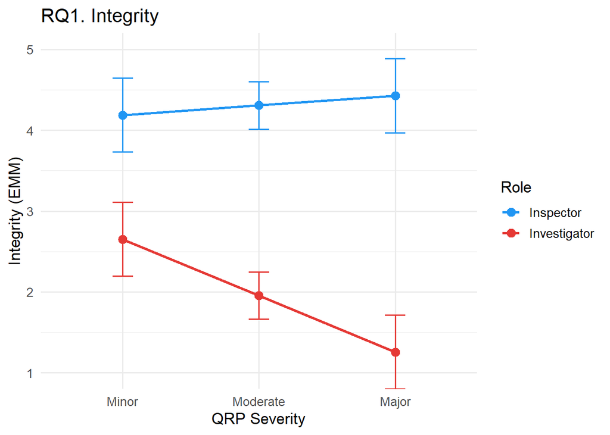

```r
emm_Integrity_df = as.data.frame(
  emmeans(
    T4,
    ~ role_ec * severity_num,
    at = list(severity_num = c(0,1,2))
  )
) %>%
  mutate(
    Role = if_else(
      role_ec == 1,
      "Inspector",
      "Investigator"
    ),
    Severity = factor(
      severity_num,
      levels = c(0,1,2),
      labels = c("Minor", "Moderate", "Major")
    )
  )

ggplot(
  emm_Integrity_df,
  aes(
    x = Severity,
    y = emmean,
    color = Role,
    group = Role
  )
) +
  geom_line(linewidth = 1) +
  geom_point(size = 3) +
  geom_errorbar(
    aes(ymin = lower.CL, ymax = upper.CL),
    width = 0.15
  ) +
  scale_color_manual(
    values = c(
      "Inspector" = "#2196F3",
      "Investigator" = "#E53935"
    )
  ) +
  labs(
    title = "RQ1. Integrity",
    y = "Integrity (EMM)",
    x = "QRP Severity"
  ) +
  theme_minimal(base_size = 13) +
  coord_cartesian(ylim = c(1, 5))
```

##Likeability

**Research Question 2: How is likeability influenced by role and QRP severity?**

**Hypothesis 2a:** Investigators will be rated more likeable than inspectors.

**Hypothesis 2b:** At low QRP severity, investigators will be rated more likeable than inspectors, but at high QRP severity, inspectors will be rated more likeable than investigators.

###Random-effects structure for Likeability

```r
L4_max1 = lmer(
  likeability ~ role_ec * severity_num +
    (1 + role_ec * severity_num | responseid),
  data = tl_dat,
  REML = FALSE,
  control = lmerControl(optimizer = "bobyqa")
)
```

```
## boundary (singular) fit: see help('isSingular')
```

```r
L4_max1_singular = isSingular(L4_max1, tol = 1e-4)
print(L4_max1_singular)
```

```
## [1] TRUE
```

```r
# Step down: remove random interaction slope.
L4_max2 = lmer(
  likeability ~ role_ec * severity_num +
    (1 + role_ec + severity_num | responseid),
  data = tl_dat,
  REML = FALSE,
  control = lmerControl(optimizer = "bobyqa")
)
```

```
## boundary (singular) fit: see help('isSingular')
```

```r
L4_max2_singular = isSingular(L4_max2, tol = 1e-4)
print(L4_max2_singular)
```

```
## [1] TRUE
```

```r
# Step down: retain random role slope only.
L4_max3 = lmer(
  likeability ~ role_ec * severity_num +
    (1 + role_ec | responseid),
  data = tl_dat,
  REML = FALSE,
  control = lmerControl(optimizer = "bobyqa")
)

L4_max3_singular = isSingular(L4_max3, tol = 1e-4)
print(L4_max3_singular)
```

```
## [1] FALSE
```

```r
# Test preregistered vignette random intercept with the maximal
# participant-level structure.
L4_prereg = lmer(
  likeability ~ role_ec * severity_num +
    (1 + role_ec * severity_num | responseid) +
    (1 | vignette_id),
  data = tl_dat,
  REML = FALSE,
  control = lmerControl(optimizer = "bobyqa")
)
```

```
## boundary (singular) fit: see help('isSingular')
```

```r
L4_prereg_singular = isSingular(L4_prereg, tol = 1e-4)
print(L4_prereg_singular)
```

```
## [1] TRUE
```

```r
likeability_uses_vignette_term = !L4_prereg_singular

cat(
  "Likeability final random-effects structure includes vignette intercept:",
  likeability_uses_vignette_term,
  "\n"
)
```

```
## Likeability final random-effects structure includes vignette intercept: FALSE
```

###step-up models

```r
if (likeability_uses_vignette_term) {

  random_part_likeability = "participant_maximal_plus_vignette"

  M0_like = lmer(
    likeability ~ 1 +
      (1 + role_ec * severity_num | responseid) +
      (1 | vignette_id),
    data = tl_dat,
    REML = FALSE,
    control = lmerControl(optimizer = "bobyqa")
  )

  L1 = lmer(
    likeability ~ role_ec +
      (1 + role_ec * severity_num | responseid) +
      (1 | vignette_id),
    data = tl_dat,
    REML = FALSE,
    control = lmerControl(optimizer = "bobyqa")
  )

  L2 = lmer(
    likeability ~ severity_num +
      (1 + role_ec * severity_num | responseid) +
      (1 | vignette_id),
    data = tl_dat,
    REML = FALSE,
    control = lmerControl(optimizer = "bobyqa")
  )

  L3 = lmer(
    likeability ~ role_ec + severity_num +
      (1 + role_ec * severity_num | responseid) +
      (1 | vignette_id),
    data = tl_dat,
    REML = FALSE,
    control = lmerControl(optimizer = "bobyqa")
  )

  L4 = L4_prereg

} else {

  random_part_likeability = "participant_maximal"

  M0_like = lmer(
    likeability ~ 1 +
      (1 + role_ec * severity_num | responseid),
    data = tl_dat,
    REML = FALSE,
    control = lmerControl(optimizer = "bobyqa")
  )

  L1 = lmer(
    likeability ~ role_ec +
      (1 + role_ec * severity_num | responseid),
    data = tl_dat,
    REML = FALSE,
    control = lmerControl(optimizer = "bobyqa")
  )

  L2 = lmer(
    likeability ~ severity_num +
      (1 + role_ec * severity_num | responseid),
    data = tl_dat,
    REML = FALSE,
    control = lmerControl(optimizer = "bobyqa")
  )

  L3 = lmer(
    likeability ~ role_ec + severity_num +
      (1 + role_ec * severity_num | responseid),
    data = tl_dat,
    REML = FALSE,
    control = lmerControl(optimizer = "bobyqa")
  )

  L4 = L4_max1
}
```

```
## boundary (singular) fit: see help('isSingular')
## boundary (singular) fit: see help('isSingular')
## boundary (singular) fit: see help('isSingular')
```

```
## boundary (singular) fit: see help('isSingular')
```

```r
cat("Likeability final model singularity:\n")
```

```
## Likeability final model singularity:
```

```r
print(isSingular(M0_like))
```

```
## [1] TRUE
```

```r
print(isSingular(L1))
```

```
## [1] TRUE
```

```r
print(isSingular(L2))
```

```
## [1] TRUE
```

```r
print(isSingular(L3))
```

```
## [1] TRUE
```

```r
print(isSingular(L4))
```

```
## [1] TRUE
```

```r
likeability_models = list(
  M0_like,
  L1,
  L2,
  L3,
  L4
)

likeability_model_names = c(
  "Model 0: Null",
  "Model 2a: Role",
  "Model 2b: QRP Severity",
  "Model 2c: Role + QRP Severity",
  "Model 2d: Role × QRP Severity"
)

likeability_fit = model_fit_table(
  likeability_models,
  likeability_model_names
)

print(likeability_fit)
```

```
##                           Model    AIC
## 1                 Model 0: Null 6690.9
## 2                Model 2a: Role 6507.6
## 3        Model 2b: QRP Severity 6685.7
## 4 Model 2c: Role + QRP Severity 6453.1
## 5 Model 2d: Role × QRP Severity 6185.3
##      BIC  logLik  Chisq df      p
## 1 6761.6 -3333.5      —  —      —
## 2 6584.2 -3240.8 185.29  1 < .001
## 3 6762.3 -3329.8   0.00  0      —
## 4 6535.6 -3212.5 234.55  1 < .001
## 5 6273.7 -3077.7 269.76  1 < .001
```

```r
summary(L1)
```

```
## Linear mixed model fit by maximum
##   likelihood . t-tests use Satterthwaite's
##   method [lmerModLmerTest]
## Formula:
## likeability ~ role_ec + (1 + role_ec * severity_num | responseid)
##    Data: tl_dat
## Control: lmerControl(optimizer = "bobyqa")
##
##       AIC       BIC    logLik -2*log(L)
##    6507.6    6584.2   -3240.8    6481.6
##  df.resid
##      2665
##
## Scaled residuals:
##     Min      1Q  Median      3Q     Max
## -5.1639 -0.4499  0.0152  0.4711  3.4301
##
## Random effects:
##  Groups     Name                 Variance
##  responseid (Intercept)          0.12907
##             role_ec              0.28690
##             severity_num         0.02756
##             role_ec:severity_num 0.15863
##  Residual                        0.37339
##  Std.Dev. Corr
##  0.3593
##  0.5356    0.14
##  0.1660   -0.69  0.07
##  0.3983    0.45 -0.45 -0.91
##  0.6111
## Number of obs: 2678, groups:
## responseid, 448
##
## Fixed effects:
##              Estimate Std. Error        df
## (Intercept)   3.12119    0.01741 448.49221
## role_ec       0.55199    0.02536 448.75703
##             t value Pr(>|t|)
## (Intercept)  179.31   <2e-16 ***
## role_ec       21.77   <2e-16 ***
## ---
## Signif. codes:
##   0 '***' 0.001 '**' 0.01 '*' 0.05 '.' 0.1  ' ' 1
##
## Correlation of Fixed Effects:
##         (Intr)
## role_ec 0.162
## optimizer (bobyqa) convergence code: 0 (OK)
## boundary (singular) fit: see help('isSingular')
```

```r
summary(L2)
```

```
## Linear mixed model fit by maximum
##   likelihood . t-tests use Satterthwaite's
##   method [lmerModLmerTest]
## Formula:
## likeability ~ severity_num + (1 + role_ec * severity_num | responseid)
##    Data: tl_dat
## Control: lmerControl(optimizer = "bobyqa")
##
##       AIC       BIC    logLik -2*log(L)
##    6685.7    6762.3   -3329.8    6659.7
##  df.resid
##      2665
##
## Scaled residuals:
##     Min      1Q  Median      3Q     Max
## -4.3964 -0.4608  0.0090  0.4759  3.9509
##
## Random effects:
##  Groups     Name                 Variance
##  responseid (Intercept)          0.118056
##             role_ec              0.345141
##             severity_num         0.007998
##             role_ec:severity_num 0.157013
##  Residual                        0.369243
##  Std.Dev. Corr
##  0.34359
##  0.58749   0.55
##  0.08943  -0.75 -0.97
##  0.39625   0.28  0.40 -0.40
##  0.60765
## Number of obs: 2678, groups:
## responseid, 448
##
## Fixed effects:
##                Estimate Std. Error
## (Intercept)     3.17641    0.02327
## severity_num   -0.11187    0.01455
##                      df t value Pr(>|t|)
## (Intercept)   507.90307  136.51  < 2e-16 ***
## severity_num 1266.83668   -7.69 2.94e-14 ***
## ---
## Signif. codes:
##   0 '***' 0.001 '**' 0.01 '*' 0.05 '.' 0.1  ' ' 1
##
## Correlation of Fixed Effects:
##             (Intr)
## severity_nm -0.675
## optimizer (bobyqa) convergence code: 0 (OK)
## boundary (singular) fit: see help('isSingular')
```

```r
summary(L3)
```

```
## Linear mixed model fit by maximum
##   likelihood . t-tests use Satterthwaite's
##   method [lmerModLmerTest]
## Formula:
## likeability ~ role_ec + severity_num + (1 + role_ec * severity_num |
##     responseid)
##    Data: tl_dat
## Control: lmerControl(optimizer = "bobyqa")
##
##       AIC       BIC    logLik -2*log(L)
##    6453.1    6535.6   -3212.5    6425.1
##  df.resid
##      2664
##
## Scaled residuals:
##     Min      1Q  Median      3Q     Max
## -4.5824 -0.4560  0.0290  0.4649  4.0097
##
## Random effects:
##  Groups     Name                 Variance
##  responseid (Intercept)          0.102631
##             role_ec              0.318237
##             severity_num         0.005659
##             role_ec:severity_num 0.159915
##  Residual                        0.366977
##  Std.Dev. Corr
##  0.32036
##  0.56412   0.35
##  0.07522  -0.68 -0.61
##  0.39989   0.05 -0.51 -0.32
##  0.60579
## Number of obs: 2678, groups:
## responseid, 448
##
## Fixed effects:
##                Estimate Std. Error
## (Intercept)     3.29162    0.02393
## role_ec         0.60874    0.02590
## severity_num   -0.15212    0.01476
##                      df t value Pr(>|t|)
## (Intercept)   490.92711  137.55   <2e-16 ***
## role_ec       447.65368   23.50   <2e-16 ***
## severity_num 1067.58209  -10.31   <2e-16 ***
## ---
## Signif. codes:
##   0 '***' 0.001 '**' 0.01 '*' 0.05 '.' 0.1  ' ' 1
##
## Correlation of Fixed Effects:
##             (Intr) role_c
## role_ec      0.252
## severity_nm -0.686 -0.198
## optimizer (bobyqa) convergence code: 0 (OK)
## boundary (singular) fit: see help('isSingular')
```

```r
summary(L4)
```

```
## Linear mixed model fit by maximum
##   likelihood . t-tests use Satterthwaite's
##   method [lmerModLmerTest]
## Formula:
## likeability ~ role_ec * severity_num + (1 + role_ec * severity_num |
##     responseid)
##    Data: tl_dat
## Control: lmerControl(optimizer = "bobyqa")
##
##       AIC       BIC    logLik -2*log(L)
##    6185.3    6273.7   -3077.7    6155.3
##  df.resid
##      2663
##
## Scaled residuals:
##     Min      1Q  Median      3Q     Max
## -4.9532 -0.4833  0.0196  0.5209  4.1920
##
## Random effects:
##  Groups     Name                 Variance
##  responseid (Intercept)          0.102638
##             role_ec              0.239689
##             severity_num         0.005489
##             role_ec:severity_num 0.045546
##  Residual                        0.367035
##  Std.Dev. Corr
##  0.32037
##  0.48958   0.42
##  0.07409  -0.69 -0.81
##  0.21342   0.05 -0.20 -0.33
##  0.60583
## Number of obs: 2678, groups:
## responseid, 448
##
## Fixed effects:
##                        Estimate Std. Error
## (Intercept)             3.30072    0.02394
## role_ec                 0.32966    0.02966
## severity_num           -0.16479    0.01477
## role_ec:severity_num    0.33796    0.01755
##                              df t value
## (Intercept)           490.29423  137.88
## role_ec               447.45723   11.12
## severity_num         1053.96150  -11.16
## role_ec:severity_num  446.68198   19.26
##                      Pr(>|t|)
## (Intercept)            <2e-16 ***
## role_ec                <2e-16 ***
## severity_num           <2e-16 ***
## role_ec:severity_num   <2e-16 ***
## ---
## Signif. codes:
##   0 '***' 0.001 '**' 0.01 '*' 0.05 '.' 0.1  ' ' 1
##
## Correlation of Fixed Effects:
##             (Intr) role_c svrty_
## role_ec      0.210
## severity_nm -0.686 -0.150
## rl_c:svrty_  0.019 -0.487 -0.044
## optimizer (bobyqa) convergence code: 0 (OK)
## boundary (singular) fit: see help('isSingular')
```

###fixed effects and planned role contrasts

```r
likeability_fixed_effects = lapply(
  likeability_models,
  get_fixed_effects
)

names(likeability_fixed_effects) = paste0("Model_", 0:4)

print(likeability_fixed_effects)
```

```
## $Model_0
##     Parameter        b         SE       df
## 1 (Intercept) 3.059204 0.01717914 448.1121
##          t p
## 1 178.0767 0
##
## $Model_1
##     Parameter         b         SE       df
## 1 (Intercept) 3.1211870 0.01740673 448.4922
## 2     role_ec 0.5519877 0.02535524 448.7570
##           t            p
## 1 179.30924 0.000000e+00
## 2  21.77016 3.007759e-72
##
## $Model_2
##      Parameter          b         SE
## 1  (Intercept)  3.1764104 0.02326860
## 2 severity_num -0.1118743 0.01454809
##          df          t            p
## 1  507.9031 136.510572 0.000000e+00
## 2 1266.8367  -7.689963 2.940163e-14
##
## $Model_3
##      Parameter          b         SE
## 1  (Intercept)  3.2916162 0.02392966
## 2      role_ec  0.6087376 0.02590163
## 3 severity_num -0.1521180 0.01475628
##          df        t            p
## 1  490.9271 137.5538 0.000000e+00
## 2  447.6537  23.5019 3.771360e-80
## 3 1067.5821 -10.3087 8.067739e-24
##
## $Model_4
##              Parameter          b         SE
## 1          (Intercept)  3.3007156 0.02393916
## 2              role_ec  0.3296555 0.02965651
## 3         severity_num -0.1647914 0.01477082
## 4 role_ec:severity_num  0.3379600 0.01754750
##          df         t            p
## 1  490.2942 137.87935 0.000000e+00
## 2  447.4572  11.11579 1.632282e-25
## 3 1053.9615 -11.15655 2.126074e-27
## 4  446.6820  19.25973 1.283569e-60
```

```r
# Planned role comparisons at each severity.
emm_like_role = emmeans(
  L4,
  pairwise ~ role_ec | severity_num,
  at = list(severity_num = c(0,1,2)),
  adjust = "bonferroni"
)
```

```
## boundary (singular) fit: see help('isSingular')
```

```r
summary(emm_like_role$contrasts)
```

```
## severity_num = 0:
##  contrast               estimate     SE  df
##  (role_ec-1) - role_ec1   -0.659 0.0594 448
##  t.ratio p.value
##  -11.103 <0.0001
##
## severity_num = 1:
##  contrast               estimate     SE  df
##  (role_ec-1) - role_ec1   -1.335 0.0522 448
##  t.ratio p.value
##  -25.567 <0.0001
##
## severity_num = 2:
##  contrast               estimate     SE  df
##  (role_ec-1) - role_ec1   -2.011 0.0663 448
##  t.ratio p.value
##  -30.326 <0.0001
##
## Degrees-of-freedom method: kenward-roger
```

```r
# Cohen's d for each role comparison.
eff_size(
  emmeans(
    L4,
    ~ role_ec | severity_num,
    at = list(severity_num = c(0,1,2))
  ),
  sigma = sigma(L4),
  edf = df.residual(L4)
)
```

```
## boundary (singular) fit: see help('isSingular')
```

```
## severity_num = 0:
##  contrast               effect.size     SE
##  (role_ec-1) - role_ec1       -1.09 0.0991
##   df lower.CL upper.CL
##  447    -1.28   -0.893
##
## severity_num = 1:
##  contrast               effect.size     SE
##  (role_ec-1) - role_ec1       -2.20 0.0913
##   df lower.CL upper.CL
##  448    -2.38   -2.024
##
## severity_num = 2:
##  contrast               effect.size     SE
##  (role_ec-1) - role_ec1       -3.32 0.1190
##   df lower.CL upper.CL
##  448    -3.55   -3.087
##
## sigma used for effect sizes: 0.6058
## Degrees-of-freedom method: inherited from kenward-roger when re-gridding
## Confidence level used: 0.95
```

###figure

```r
emm_like_df = as.data.frame(
  emmeans(
    L4,
    ~ role_ec * severity_num,
    at = list(severity_num = c(0,1,2))
  )
) %>%
  mutate(
    Role = if_else(
      role_ec == 1,
      "Inspector",
      "Investigator"
    ),
    Severity = factor(
      severity_num,
      levels = c(0,1,2),
      labels = c("Minor", "Moderate", "Major")
    )
  )
```

```
## boundary (singular) fit: see help('isSingular')
```

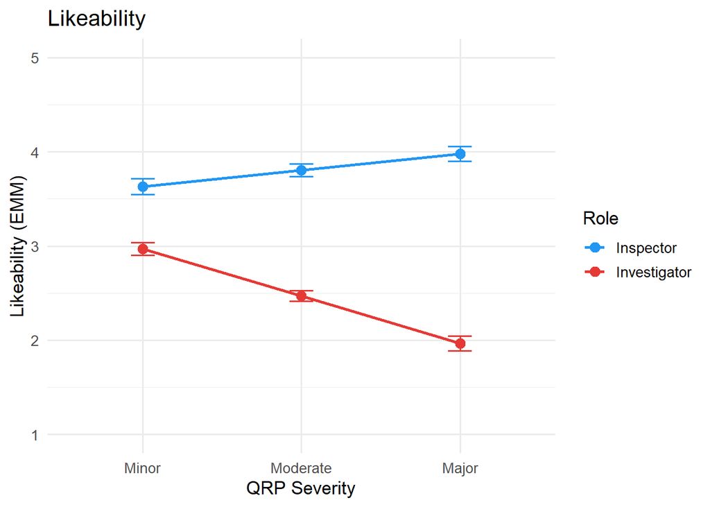

```r
ggplot(
  emm_like_df,
  aes(
    x = Severity,
    y = emmean,
    color = Role,
    group = Role
  )
) +
  geom_line(linewidth = 1) +
  geom_point(size = 3) +
  geom_errorbar(
    aes(ymin = lower.CL, ymax = upper.CL),
    width = 0.15
  ) +
  scale_color_manual(
    values = c(
      "Inspector" = "#2196F3",
      "Investigator" = "#E53935"
    )
  ) +
  labs(
    title = "Likeability",
    y = "Likeability (EMM)",
    x = "QRP Severity"
  ) +
  theme_minimal(base_size = 13) +
  coord_cartesian(ylim = c(1, 5))
```

##TRUENESS

Research Question 3: Is the perceived trueness of the finding influenced by QRP severity?**

**Hypothesis 3:** Perceived trueness will decrease as QRP severity increases.

###data and model

```r
# Trueness is only rated for investigators, with one item per vignette.
trueness_dat = filtered_by_age %>%
  transmute(
    responseid,
    minor = parse_num(kcon),
    moderate = parse_num(hcon),
    major = parse_num(xcon)
  ) %>%
  pivot_longer(
    cols = c(minor, moderate, major),
    names_to = "severity",
    values_to = "trueness"
  ) %>%
  mutate(
    severity = factor(
      severity,
      levels = c("minor", "moderate", "major")
    ),
    severity_num = case_when(
      severity == "minor" ~ 0,
      severity == "moderate" ~ 1,
      severity == "major" ~ 2
    ),
    responseid = factor(responseid),
    trueness_c = trueness - 3
  )


# Descriptives.
trueness_descriptives = trueness_dat %>%
  group_by(severity) %>%
  summarise(
    n = sum(!is.na(trueness)),
    M = round(mean(trueness, na.rm = TRUE), 2),
    SD = round(sd(trueness, na.rm = TRUE), 2),
    .groups = "drop"
  )

print(trueness_descriptives)
```

```
## # A tibble: 3 × 4
##   severity     n     M    SD
##   <fct>    <int> <dbl> <dbl>
## 1 minor      446  2.98  0.91
## 2 moderate   447  1.86  0.92
## 3 major      447  1.53  0.88
```

```r
range(trueness_dat$trueness, na.rm = TRUE)
```

```
## [1] 1 5
```

```r
mean(trueness_dat$trueness, na.rm = TRUE)
```

```
## [1] 2.122388
```

```r
# FT1: perceived trueness predicted by QRP severity.
FT1 = lmer(
  trueness_c ~ severity_num +
    (1 | responseid) +
    (1 | severity),
  data = trueness_dat,
  REML = FALSE,
  control = lmerControl(optimizer = "bobyqa")
)

summary(FT1)
```

```
## Linear mixed model fit by maximum
##   likelihood . t-tests use Satterthwaite's
##   method [lmerModLmerTest]
## Formula:
## trueness_c ~ severity_num + (1 | responseid) + (1 | severity)
##    Data: trueness_dat
## Control: lmerControl(optimizer = "bobyqa")
##
##       AIC       BIC    logLik -2*log(L)
##    3503.7    3529.7   -1746.8    3493.7
##  df.resid
##      1335
##
## Scaled residuals:
##     Min      1Q  Median      3Q     Max
## -2.7309 -0.6556 -0.0754  0.4459  4.0079
##
## Random effects:
##  Groups     Name        Variance Std.Dev.
##  responseid (Intercept) 0.16689  0.4085
##  severity   (Intercept) 0.03313  0.1820
##  Residual               0.65229  0.8076
## Number of obs: 1340, groups:
## responseid, 448; severity, 3
##
## Fixed effects:
##              Estimate Std. Error      df
## (Intercept)   -0.1558     0.1709  3.0775
## severity_num  -0.7213     0.1315  2.9993
##              t value Pr(>|t|)
## (Intercept)   -0.912   0.4276
## severity_num  -5.485   0.0119 *
## ---
## Signif. codes:
##   0 '***' 0.001 '**' 0.01 '*' 0.05 '.' 0.1  ' ' 1
##
## Correlation of Fixed Effects:
##             (Intr)
## severity_nm -0.770
```

```r
isSingular(FT1)
```

```
## [1] FALSE
```

```r
# Fixed effects, including Satterthwaite df, t, and p.
trueness_fixed_effects = get_fixed_effects(FT1)
print(trueness_fixed_effects)
```

```
##      Parameter          b        SE       df
## 1  (Intercept) -0.1557875 0.1708682 3.077470
## 2 severity_num -0.7212843 0.1315047 2.999292
##            t          p
## 1 -0.9117408 0.42758909
## 2 -5.4848567 0.01192804
```

```r
# Planned comparisons across severity levels.
emm_trueness = emmeans(
  FT1,
  pairwise ~ severity_num,
  at = list(severity_num = c(0,1,2)),
  adjust = "bonferroni"
)

summary(emm_trueness$contrasts)
```

```
##  contrast                      estimate
##  severity_num0 - severity_num1    0.721
##  severity_num0 - severity_num2    1.443
##  severity_num1 - severity_num2    0.721
##     SE   df t.ratio p.value
##  0.227 8.81   3.183  0.0343
##  0.453 8.81   3.183  0.0343
##  0.227 8.81   3.183  0.0343
##
## Degrees-of-freedom method: kenward-roger
## P value adjustment: bonferroni method for 3 tests
```

```r
eff_size(
  emmeans(
    FT1,
    ~ severity_num,
    at = list(severity_num = c(0,1,2))
  ),
  sigma = sigma(FT1),
  edf = df.residual(FT1)
)
```

```
##  contrast                      effect.size
##  severity_num0 - severity_num1       0.893
##  severity_num0 - severity_num2       1.786
##  severity_num1 - severity_num2       0.893
##     SE   df lower.CL upper.CL
##  0.281 8.64    0.253     1.53
##  0.562 8.74    0.509     3.06
##  0.281 8.64    0.253     1.53
##
## sigma used for effect sizes: 0.8076
## Degrees-of-freedom method: inherited from kenward-roger when re-gridding
## Confidence level used: 0.95
```

###figure

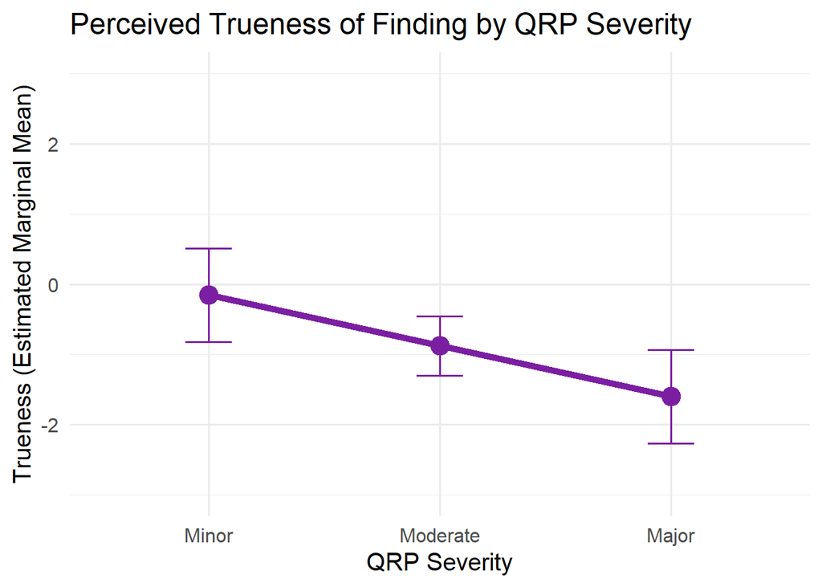

```r
emm_true_df = as.data.frame(
  emmeans(
    FT1,
    ~ severity_num,
    at = list(severity_num = c(0,1,2))
  )
) %>%
  mutate(
    Severity = factor(
      severity_num,
      levels = c(0,1,2),
      labels = c("Minor", "Moderate", "Major")
    )
  )

ggplot(
  emm_true_df,
  aes(
    x = Severity,
    y = emmean,
    group = 1
  )
) +
  geom_line(linewidth = 2, color = "#7B1FA2") +
  geom_point(size = 5, color = "#7B1FA2") +
  geom_errorbar(
    aes(ymin = lower.CL, ymax = upper.CL),
    width = 0.20,
    color = "#7B1FA2"
  ) +
  labs(
    title = "Perceived Trueness of Finding by QRP Severity",
    y = "Trueness (Estimated Marginal Mean)",
    x = "QRP Severity"
  ) +
  theme_minimal(base_size = 15) +
  coord_cartesian(ylim = c(-3, 3))
```

##Robustness checks — demographic covariates

```r
demo_dat = filtered_by_age %>%
  transmute(
    responseid = responseid,
    gender = factor(`gender.identity`),
    political = factor(
      political,
      levels = c(
        "Strongly Liberal",
        "Liberal",
        "Lean Liberal",
        "Centrist",
        "Lean Conservative",
        "Conservative",
        "Strongly Conservative"
      )
    ),
    religion = factor(religion)
  )

tl_robust = tl_dat %>%
  mutate(responseid = as.character(responseid)) %>%
  left_join(demo_dat, by = "responseid") %>%
  mutate(responseid = factor(responseid))


# Integrity robustness model uses the exact random-effects structure

if (Integrity_uses_vignette_term) {

  T4_robust = lmer(
    Integrity ~ role_ec * severity_num +
      gender + political + religion +
      (1 + role_ec | responseid) +
      (1 | vignette_id),
    data = tl_robust,
    REML = FALSE,
    control = lmerControl(optimizer = "bobyqa")
  )

} else {

  T4_robust = lmer(
    Integrity ~ role_ec * severity_num +
      gender + political + religion +
      (1 + role_ec | responseid),
    data = tl_robust,
    REML = FALSE,
    control = lmerControl(optimizer = "bobyqa")
  )
}


# Likeability robustness model uses the exact random-effects structure

if (likeability_uses_vignette_term) {

  L4_robust = lmer(
    likeability ~ role_ec * severity_num +
      gender + political + religion +
      (1 + role_ec * severity_num | responseid) +
      (1 | vignette_id),
    data = tl_robust,
    REML = FALSE,
    control = lmerControl(optimizer = "bobyqa")
  )

} else {

  L4_robust = lmer(
    likeability ~ role_ec * severity_num +
      gender + political + religion +
      (1 + role_ec * severity_num | responseid),
    data = tl_robust,
    REML = FALSE,
    control = lmerControl(optimizer = "bobyqa")
  )
}
```

```
## boundary (singular) fit: see help('isSingular')
```

```r
summary(T4_robust)
```

```
## Linear mixed model fit by maximum
##   likelihood . t-tests use Satterthwaite's
##   method [lmerModLmerTest]
## Formula:
## Integrity ~ role_ec * severity_num + gender + political + religion +
##     (1 + role_ec | responseid) + (1 | vignette_id)
##    Data: tl_robust
## Control: lmerControl(optimizer = "bobyqa")
##
##       AIC       BIC    logLik -2*log(L)
##    5599.2    5733.8   -2776.6    5553.2
##  df.resid
##      2551
##
## Scaled residuals:
##     Min      1Q  Median      3Q     Max
## -4.9084 -0.5233  0.0089  0.4967  5.4390
##
## Random effects:
##  Groups      Name        Variance Std.Dev.
##  responseid  (Intercept) 0.03990  0.1998
##              role_ec     0.16828  0.4102
##  vignette_id (Intercept) 0.01821  0.1350
##  Residual                0.37452  0.6120
##  Corr
##
##  0.33
##
##
## Number of obs: 2574, groups:
## responseid, 429; vignette_id, 6
##
## Fixed effects:
##                                     Estimate
## (Intercept)                         3.445786
## role_ec                             0.761655
## severity_num                       -0.292735
## genderNon-binary / third gender    -0.277020
## genderPrefer not to say            -0.042871
## genderWoman                        -0.015940
```

[output cut: 95 more lines]

```
## politicalLiberal
## politicalLean Liberal
## politicalCentrist
## politicalLean Conservative
## politicalConservative
## politicalStrongly Conservative
## religionIslam
## religionJudaism
## religionNot Affiliated
## religionOther                     .
## religionProtestantism (Christian)
## role_ec:severity_num              ***
## ---
## Signif. codes:
##   0 '***' 0.001 '**' 0.01 '*' 0.05 '.' 0.1  ' ' 1
```

```
##
## Correlation matrix not shown by default, as p = 18 > 12.
## Use print(x, correlation=TRUE)  or
##     vcov(x)        if you need it
```

```r
summary(L4_robust)
```

```
## Linear mixed model fit by maximum
##   likelihood . t-tests use Satterthwaite's
##   method [lmerModLmerTest]
## Formula:
## likeability ~ role_ec * severity_num + gender + political + religion +
##     (1 + role_ec * severity_num | responseid)
##    Data: tl_robust
## Control: lmerControl(optimizer = "bobyqa")
##
##       AIC       BIC    logLik -2*log(L)
##    5954.1    6123.9   -2948.1    5896.1
##  df.resid
##      2545
##
## Scaled residuals:
##     Min      1Q  Median      3Q     Max
## -4.8067 -0.4755  0.0242  0.5161  3.7559
##
## Random effects:
##  Groups     Name                 Variance
##  responseid (Intercept)          0.096619
##             role_ec              0.233166
##             severity_num         0.005683
##             role_ec:severity_num 0.043677
##  Residual                        0.368305
##  Std.Dev. Corr
##  0.31084
##  0.48287   0.44
##  0.07539  -0.69 -0.87
##  0.20899   0.04 -0.18 -0.23
##  0.60688
## Number of obs: 2574, groups:
## responseid, 429
##
## Fixed effects:
##                                     Estimate
## (Intercept)                          3.20796
## role_ec                              0.32051
## severity_num                        -0.16725
## genderNon-binary / third gender     -0.04190
```

[output cut: 97 more lines]

```
## politicalLiberal
## politicalLean Liberal
## politicalCentrist
## politicalLean Conservative
## politicalConservative
## politicalStrongly Conservative
## religionIslam
## religionJudaism
## religionNot Affiliated
## religionOther                     *
## religionProtestantism (Christian) .
## role_ec:severity_num              ***
## ---
## Signif. codes:
##   0 '***' 0.001 '**' 0.01 '*' 0.05 '.' 0.1  ' ' 1
```

```
##
## Correlation matrix not shown by default, as p = 18 > 12.
## Use print(x, correlation=TRUE)  or
##     vcov(x)        if you need it
```

```
## optimizer (bobyqa) convergence code: 0 (OK)
## boundary (singular) fit: see help('isSingular')
```

```r
# Compare interaction coefficients with and without demographic covariates.
cat("Integrity interaction, original:",
    fixef(T4)[["role_ec:severity_num"]], "\n")
```

```
## Integrity interaction, original: 0.4080529
```

```r
cat("Integrity interaction, adjusted:",
    fixef(T4_robust)[["role_ec:severity_num"]], "\n")
```

```
## Integrity interaction, adjusted: 0.4162782
```

```r
cat("Likeability interaction, original:",
    fixef(L4)[["role_ec:severity_num"]], "\n")
```

```
## Likeability interaction, original: 0.33796
```

```r
cat("Likeability interaction, adjusted:",
    fixef(L4_robust)[["role_ec:severity_num"]], "\n")
```

```
## Likeability interaction, adjusted: 0.3455711
```

# APA TABLES

```r
#APA Model Comparison Tables

# Helper: extract fixed effects from a model into a clean data frame
fe_table = function(model) {
  cf = summary(model)$coefficients
  ci = confint(model, method = "Wald")
  ci = ci[rownames(cf), ]

  data.frame(
    Parameter = rownames(cf),
    b         = round(cf[, "Estimate"], 2),
    SE        = round(cf[, "Std. Error"], 2),
    df        = round(cf[, "df"], 2),
    CI_low    = round(ci[, 1], 2),
    CI_high   = round(ci[, 2], 2),
    t         = round(cf[, "t value"], 2),
    p         = ifelse(
      cf[, "Pr(>|t|)"] < .001,
      "< .001",
      formatC(cf[, "Pr(>|t|)"], digits = 3, format = "f")
    )
  )
}


relabel = function(df) {
  df$Parameter = dplyr::recode(
    df$Parameter,
    "(Intercept)"          = "Intercept",
    "role_ec"              = "Role",
    "severity_num"         = "QRP Severity",
    "role_ec:severity_num" = "Role × QRP Severity"
  )
  df
}


fit_table = function(model_list, model_names) {

  do.call(
    rbind,
    lapply(seq_along(model_list), function(i) {

      m = model_list[[i]]

      if (i == 1) {

        chisq_out = NA_character_
        df_out    = NA_character_
        p_out     = NA_character_

      } else {

        lr = anova(
          model_list[[i - 1]],
          m
        )

        chisq_out = formatC(
          lr$Chisq[2],
          digits = 2,
          format = "f"
        )

        df_out = as.character(
          lr$Df[2]
        )

        p_out = ifelse(
          lr$`Pr(>Chisq)`[2] < .001,
          "< .001",
          formatC(
            lr$`Pr(>Chisq)`[2],
            digits = 3,
            format = "f"
          )
        )
      }

      data.frame(
        Model  = model_names[i],
        AIC    = round(AIC(m), 1),
        BIC    = round(BIC(m), 1),
        logLik = round(as.numeric(logLik(m)), 1),
        Chisq  = chisq_out,
        df     = df_out,
        p      = p_out
      )
    })
  )
}


#TABLE 1: Integrity model fit

fit_table(
  list(
    T1,
    T2,
    T3,
    T4
  ),
  c(
    "M1a: Role",
    "M1b: Severity",
    "M1c: Role + Severity",
    "M1d: Role × Severity"
  )
) %>%

  kable(
    caption = "Table 1. Model Fit Indices for Step-Up Integrity Models",
    col.names = c(
      "Model",
      "AIC",
      "BIC",
      "logLik",
      "$\\chi^2$",
      "df",
      "p"
    ),
    align = "lrrrrrr",
    escape = FALSE
  ) %>%

  kable_styling(
    full_width = FALSE,
    bootstrap_options = "condensed"
  ) %>%

  footnote(
    general =
      "Lower AIC/BIC indicates better model fit. Chi-square tests reflect likelihood ratio comparison to the preceding model."
  )
```

Table 1. Model Fit Indices for Step-Up Integrity Models

| Model | AIC | BIC | logLik | $\chi^2$ | df | p |
| --- | --- | --- | --- | --- | --- | --- |
| M1a: Role | 5815.5 | 5856.7 | -2900.7 | NA | NA | NA |
| M1b: Severity | 5828.1 | 5869.3 | -2907.0 | 0.00 | 0 | NA |
| M1c: Role + Severity | 5815.3 | 5862.5 | -2899.7 | 14.72 | 1 | < .001 |
| M1d: Role × Severity | 5805.8 | 5858.9 | -2893.9 | 11.52 | 1 | < .001 |

Note:  
Lower AIC/BIC indicates better model fit. Chi-square tests reflect likelihood ratio comparison to the preceding model.

```r
#TABLE 2: Integrity fixed effects (Model 4)

fe_table(T4) %>%

  relabel() %>%

  mutate(
    `95% CI` =
      paste0(
        "[",
        CI_low,
        ", ",
        CI_high,
        "]"
      )
  ) %>%

  select(
    Parameter,
    b,
    SE,
    df,
    `95% CI`,
    t,
    p
  ) %>%

  kable(
    caption =
      "Table 2. Fixed Effects for Integrity Model 4 (Role × QRP Severity)",

    col.names = c(
      "Parameter",
      "b",
      "SE",
      "df",
      "95% CI",
      "t",
      "p"
    ),

    align = "lrrrrrr"
  ) %>%

  kable_styling(
    full_width = FALSE,
    bootstrap_options = "condensed"
  ) %>%

  footnote(
    general =
      "Role: inspector = 1, investigator = −1. QRP Severity: minor = 0, moderate = 1, major = 2."
  )
```

Table 2. Fixed Effects for Integrity Model 4 (Role × QRP Severity)

|  | Parameter | b | SE | df | 95% CI | t | p |
| --- | --- | --- | --- | --- | --- | --- | --- |
| (Intercept) | Intercept | 3.42 | 0.09 | 6.13 | [3.24, 3.6] | 38.18 | < .001 |
| role_ec | Role | 0.77 | 0.09 | 6.57 | [0.59, 0.95] | 8.43 | < .001 |
| severity_num | QRP Severity | -0.29 | 0.07 | 5.99 | [-0.42, -0.15] | -4.19 | 0.006 |
| role_ec:severity_num | Role × QRP Severity | 0.41 | 0.07 | 5.99 | [0.27, 0.54] | 5.92 | 0.001 |

Note:  
Role: inspector = 1, investigator = −1. QRP Severity: minor = 0, moderate = 1, major = 2.

```r
# TABLE 3: Likeability model fit

fit_table(
  list(
    L1,
    L2,
    L3,
    L4
  ),
  c(
    "M2a: Role",
    "M2b: Severity",
    "M2c: Role + Severity",
    "M2d: Role × Severity"
  )
) %>%

  kable(
    caption =
      "Table 3. Model Fit Indices for Step-Up Likeability Models",

    col.names = c(
      "Model",
      "AIC",
      "BIC",
      "logLik",
      "$\\chi^2$",
      "df",
      "p"
    ),

    align = "lrrrrrr",
    escape = FALSE
  ) %>%

  kable_styling(
    full_width = FALSE,
    bootstrap_options = "condensed"
  ) %>%

  footnote(
    general =
      "Lower AIC/BIC indicates better model fit. Chi-square tests reflect likelihood ratio comparison to the preceding model."
  )
```

Table 3. Model Fit Indices for Step-Up Likeability Models

| Model | AIC | BIC | logLik | $\chi^2$ | df | p |
| --- | --- | --- | --- | --- | --- | --- |
| M2a: Role | 6507.6 | 6584.2 | -3240.8 | NA | NA | NA |
| M2b: Severity | 6685.7 | 6762.3 | -3329.8 | 0.00 | 0 | NA |
| M2c: Role + Severity | 6453.1 | 6535.6 | -3212.5 | 234.55 | 1 | < .001 |
| M2d: Role × Severity | 6185.3 | 6273.7 | -3077.7 | 269.76 | 1 | < .001 |

Note:  
Lower AIC/BIC indicates better model fit. Chi-square tests reflect likelihood ratio comparison to the preceding model.

```r
#TABLE 4: Likeability fixed effects (Model 4)

fe_table(L4) %>%

  relabel() %>%

  mutate(
    `95% CI` =
      paste0(
        "[",
        CI_low,
        ", ",
        CI_high,
        "]"
      )
  ) %>%

  select(
    Parameter,
    b,
    SE,
    df,
    `95% CI`,
    t,
    p
  ) %>%

  kable(
    caption =
      "Table 4. Fixed Effects for Likeability Model 4 (Role × QRP Severity)",

    col.names = c(
      "Parameter",
      "b",
      "SE",
      "df",
      "95% CI",
      "t",
      "p"
    ),

    align = "lrrrrrr"
  ) %>%

  kable_styling(
    full_width = FALSE,
    bootstrap_options = "condensed"
  ) %>%

  footnote(
    general =
      "Role: inspector = 1, investigator = −1. QRP Severity: minor = 0, moderate = 1, major = 2."
  )
```

Table 4. Fixed Effects for Likeability Model 4 (Role × QRP Severity)

|  | Parameter | b | SE | df | 95% CI | t | p |
| --- | --- | --- | --- | --- | --- | --- | --- |
| (Intercept) | Intercept | 3.30 | 0.02 | 490.29 | [3.25, 3.35] | 137.88 | < .001 |
| role_ec | Role | 0.33 | 0.03 | 447.46 | [0.27, 0.39] | 11.12 | < .001 |
| severity_num | QRP Severity | -0.16 | 0.01 | 1053.96 | [-0.19, -0.14] | -11.16 | < .001 |
| role_ec:severity_num | Role × QRP Severity | 0.34 | 0.02 | 446.68 | [0.3, 0.37] | 19.26 | < .001 |

Note:  
Role: inspector = 1, investigator = −1. QRP Severity: minor = 0, moderate = 1, major = 2.

```r
#TABLE 5: Trueness fixed effects (FT1)

fe_table(FT1) %>%

  relabel() %>%

  mutate(
    `95% CI` =
      paste0(
        "[",
        CI_low,
        ", ",
        CI_high,
        "]"
      )
  ) %>%

  select(
    Parameter,
    b,
    SE,
    df,
    `95% CI`,
    t,
    p
  ) %>%

  kable(
    caption =
      "Table 5. Fixed Effects for Trueness Model FT1",

    col.names = c(
      "Parameter",
      "b",
      "SE",
      "df",
      "95% CI",
      "t",
      "p"
    ),

    align = "lrrrrrr"
  ) %>%

  kable_styling(
    full_width = FALSE,
    bootstrap_options = "condensed"
  ) %>%

  footnote(
    general =
      "Trueness centered at 3 (neutral midpoint). QRP Severity: minor = 0, moderate = 1, major = 2."
  )
```

Table 5. Fixed Effects for Trueness Model FT1

|  | Parameter | b | SE | df | 95% CI | t | p |
| --- | --- | --- | --- | --- | --- | --- | --- |
| (Intercept) | Intercept | -0.16 | 0.17 | 3.08 | [-0.49, 0.18] | -0.91 | 0.428 |
| severity_num | QRP Severity | -0.72 | 0.13 | 3.00 | [-0.98, -0.46] | -5.48 | 0.012 |

Note:  
Trueness centered at 3 (neutral midpoint). QRP Severity: minor = 0, moderate = 1, major = 2.

```r
get_fe = function(model) {

  cf = summary(model)$coefficients

  list(
    b  = setNames(
      round(cf[, "Estimate"], 2),
      rownames(cf)
    ),

    se = setNames(
      round(cf[, "Std. Error"], 2),
      rownames(cf)
    ),

    df = if ("df" %in% colnames(cf)) {
      setNames(
        round(cf[, "df"], 2),
        rownames(cf)
      )
    } else {
      NULL
    },

    t = if ("t value" %in% colnames(cf)) {
      setNames(
        round(cf[, "t value"], 2),
        rownames(cf)
      )
    } else {
      NULL
    },

    p = setNames(
      cf[, "Pr(>|t|)"],
      rownames(cf)
    )
  )
}

#format p value

fmt_p = function(p) {

  if (is.na(p)) return("")

  if (p < .001) {
    return("< .001***")
  }

  stars =
    ifelse(
      p < .01, "**",
      ifelse(
        p < .05, "*",
        ""
      )
    )

  paste0(
    formatC(
      p,
      digits = 3,
      format = "f"
    ),
    stars
  )
}


#extract one fixed effect

cell = function(fe, term) {

  if (!term %in% names(fe$b)) {
    return(
      c("", "", "")
    )
  }

  c(
    as.character(fe$b[term]),
    as.character(fe$se[term]),
    fmt_p(fe$p[term])
  )
}

#Random effects

get_re = function(model) {

  vc = as.data.frame(
    lme4::VarCorr(model)
  )

  setNames(
    round(vc$vcov, 3),
    vc$grp
  )
}


#ICC

get_icc = function(model) {

  vc = as.data.frame(
    lme4::VarCorr(model)
  )

  total = sum(vc$vcov)

  setNames(
    round(
      vc$vcov / total,
      3
    ),
    vc$grp
  )
}

#table set up

make_stepup_table = function(
    m0,
    m1,
    m2,
    m3,
    m4,
    caption_text,
    footnote_text
) {

  models = list(
    m0,
    m1,
    m2,
    m3,
    m4
  )

  fe_list = lapply(
    models,
    get_fe
  )

  re_list = lapply(
    models,
    get_re
  )

  icc_list = lapply(
    models,
    get_icc
  )

#fixed effect

  term_labels = c(
    "(Intercept)" =
      "Intercept",

    "role_ec" =
      "Role",

    "severity_num" =
      "QRP Severity",

    "role_ec:severity_num" =
      "Role × QRP Severity"
  )


  rows = lapply(
    names(term_labels),
    function(term) {

      cells =
        do.call(
          cbind,
          lapply(
            fe_list,
            function(fe) cell(fe, term)
          )
        )

      data.frame(

        Parameter =
          term_labels[term],

        M0_b =
          cells[1, 1],

        M0_se =
          cells[2, 1],

        M0_p =
          cells[3, 1],

        M1_b =
          cells[1, 2],

        M1_se =
          cells[2, 2],

        M1_p =
          cells[3, 2],

        M2_b =
          cells[1, 3],

        M2_se =
          cells[2, 3],

        M2_p =
          cells[3, 3],

        M3_b =
          cells[1, 4],

        M3_se =
          cells[2, 4],

        M3_p =
          cells[3, 4],

        M4_b =
          cells[1, 5],

        M4_se =
          cells[2, 5],

        M4_p =
          cells[3, 5],

        stringsAsFactors = FALSE
      )
    }
  )


  fe_df =
    do.call(
      rbind,
      rows
    )


#random effects

  re_grps = c(

    "responseid" =
      "Participant variance",

    "vignette_id" =
      "Vignette variance",

    "Residual" =
      "Residual variance"
  )


  re_rows =
    lapply(
      names(re_grps),
      function(grp) {

        vals =
          sapply(
            re_list,
            function(re) {

              if (grp %in% names(re)) {

                as.character(
                  re[grp]
                )

              } else {

                "—"
              }
            }
          )

        data.frame(

          Parameter =
            re_grps[grp],

          M0_b = vals[1],
          M0_se = "",
          M0_p = "",

          M1_b = vals[2],
          M1_se = "",
          M1_p = "",

          M2_b = vals[3],
          M2_se = "",
          M2_p = "",

          M3_b = vals[4],
          M3_se = "",
          M3_p = "",

          M4_b = vals[5],
          M4_se = "",
          M4_p = "",

          stringsAsFactors = FALSE
        )
      }
    )


  re_df =
    do.call(
      rbind,
      re_rows
    )


#ICC

  icc_rows =
    lapply(
      c(
        "responseid",
        "vignette_id"
      ),
      function(grp) {

        vals =
          sapply(
            icc_list,
            function(ic) {

              if (grp %in% names(ic)) {

                as.character(
                  ic[grp]
                )

              } else {

                "—"
              }
            }
          )

        label =
          ifelse(
            grp == "responseid",
            "ICC: Participant",
            "ICC: Vignette"
          )

        data.frame(

          Parameter = label,

          M0_b = vals[1],
          M0_se = "",
          M0_p = "",

          M1_b = vals[2],
          M1_se = "",
          M1_p = "",

          M2_b = vals[3],
          M2_se = "",
          M2_p = "",

          M3_b = vals[4],
          M3_se = "",
          M3_p = "",

          M4_b = vals[5],
          M4_se = "",
          M4_p = "",

          stringsAsFactors = FALSE
        )
      }
    )


  icc_df =
    do.call(
      rbind,
      icc_rows
    )


# AIC and BIC
  fit_vals =
    sapply(
      models,
      function(m) {

        c(
          AIC = round(
            AIC(m),
            1
          ),

          BIC = round(
            BIC(m),
            1
          )
        )
      }
    )


  fit_df =
    data.frame(

      Parameter =
        c(
          "AIC",
          "BIC"
        ),

      M0_b =
        as.character(
          fit_vals[, 1]
        ),

      M0_se = "",
      M0_p = "",

      M1_b =
        as.character(
          fit_vals[, 2]
        ),

      M1_se = "",
      M1_p = "",

      M2_b =
        as.character(
          fit_vals[, 3]
        ),

      M2_se = "",
      M2_p = "",

      M3_b =
        as.character(
          fit_vals[, 4]
        ),

      M3_se = "",
      M3_p = "",

      M4_b =
        as.character(
          fit_vals[, 5]
        ),

      M4_se = "",
      M4_p = "",

      stringsAsFactors = FALSE
    )

#model comparison

  comparisons = list()

  for (i in 2:5) {

    comp =
      anova(
        models[[i - 1]],
        models[[i]]
      )

    chi =
      comp$Chisq[2]

    df =
      comp$Df[2]

    p =
      comp$`Pr(>Chisq)`[2]

    comparisons[[i - 1]] =
      c(
        chi,
        df,
        p
      )
  }


  comparison_df =
    data.frame(

      Parameter =
        c(
          "Model comparison χ²",
          "Model comparison df",
          "Model comparison p"
        ),

      M0_b = "—",
      M0_se = "",
      M0_p = "",

      M1_b =
        as.character(
          round(
            comparisons[[1]][1],
            2
          )
        ),

      M1_se =
        as.character(
          comparisons[[1]][2]
        ),

      M1_p =
        fmt_p(
          comparisons[[1]][3]
        ),

      M2_b =
        as.character(
          round(
            comparisons[[2]][1],
            2
          )
        ),

      M2_se =
        as.character(
          comparisons[[2]][2]
        ),

      M2_p =
        fmt_p(
          comparisons[[2]][3]
        ),

      M3_b =
        as.character(
          round(
            comparisons[[3]][1],
            2
          )
        ),

      M3_se =
        as.character(
          comparisons[[3]][2]
        ),

      M3_p =
        fmt_p(
          comparisons[[3]][3]
        ),

      M4_b =
        as.character(
          round(
            comparisons[[4]][1],
            2
          )
        ),

      M4_se =
        as.character(
          comparisons[[4]][2]
        ),

      M4_p =
        fmt_p(
          comparisons[[4]][3]
        ),

      stringsAsFactors = FALSE
    )


  full_df =
    rbind(
      fe_df,
      re_df,
      icc_df,
      fit_df,
      comparison_df
    )


  full_df %>%

    kable(

      caption =
        caption_text,

      col.names =
        c(
          "Parameter",

          "b", "SE", "p",
          "b", "SE", "p",
          "b", "SE", "p",
          "b", "SE", "p",
          "b", "SE", "p"
        ),

      align =
        c(
          "l",
          rep(
            "r",
            15
          )
        ),

      escape = FALSE
    ) %>%

    kable_styling(

      full_width = TRUE,

      font_size = 11,

      bootstrap_options =
        c(
          "condensed",
          "bordered"
        )
    ) %>%

add_header_above(
  c(
    " " = 2,
    "Model 0" = 3,
    "Model 1" = 3,
    "Model 2" = 3,
    "Model 3" = 3,
    "Model 4" = 3
  )
    ) %>%

    footnote(

      general =
        footnote_text,

      general_title =
        "Note.",

      footnote_as_chunk =
        TRUE
    )
}
```

```r
make_stepup_table(

  m0 = M0_Integrity,
  m1 = T1,
  m2 = T2,
  m3 = T3,
  m4 = T4,

  caption_text =
    "Table 8. Step-Up MLM Results for Integrity Ratings",

  footnote_text =
    "Role was effect coded as inspector = 1 and investigator = −1. QRP Severity: minor = 0, moderate = 1, major = 2. Model comparison χ² values are likelihood-ratio tests comparing each model with the preceding model. * p < .05. ** p < .01. *** p < .001."
)
```

Table 8. Step-Up MLM Results for Integrity Ratings

|  | Parameter | Model 0 b | Model 0 SE | Model 0 p | Model 1 b | Model 1 SE | Model 1 p | Model 2 b | Model 2 SE | Model 2 p | Model 3 b | Model 3 SE | Model 3 p | Model 4 b | Model 4 SE | Model 4 p |
| --- | --- | --- | --- | --- | --- | --- | --- | --- | --- | --- | --- | --- | --- | --- | --- | --- |
| (Intercept) | Intercept | 3.13 | 0.51 | < .001*** | 3.13 | 0.18 | < .001*** | 3.42 | 0.79 | 0.005** | 3.42 | 0.23 | < .001*** | 3.42 | 0.09 | < .001*** |
| role_ec | Role |  |  |  | 1.18 | 0.18 | < .001*** |  |  |  | 1.18 | 0.15 | < .001*** | 0.77 | 0.09 | < .001*** |
| severity_num | QRP Severity |  |  |  |  |  |  | -0.29 | 0.61 | 0.655 | -0.29 | 0.18 | 0.160 | -0.29 | 0.07 | 0.006** |
| role_ec:severity_num | Role × QRP Severity |  |  |  |  |  |  |  |  |  |  |  |  | 0.41 | 0.07 | 0.001** |
| responseid | Participant variance | 0.041 |  |  | 0.041 |  |  | 0.041 |  |  | 0.041 |  |  | 0.041 |  |  |
| vignette_id | Vignette variance | 1.565 |  |  | 0.185 |  |  | 1.509 |  |  | 0.129 |  |  | 0.018 |  |  |
| Residual | Residual variance | 0.375 |  |  | 0.375 |  |  | 0.375 |  |  | 0.375 |  |  | 0.376 |  |  |
| 1 | ICC: Participant | 0.019 |  |  | 0.052 |  |  | 0.019 |  |  | 0.055 |  |  | 0.065 |  |  |
| 2 | ICC: Vignette | 0.719 |  |  | 0.232 |  |  | 0.712 |  |  | 0.175 |  |  | 0.029 |  |  |
| 11 | AIC | 5826.3 |  |  | 5815.5 |  |  | 5828.1 |  |  | 5815.3 |  |  | 5805.8 |  |  |
| 21 | BIC | 5861.6 |  |  | 5856.7 |  |  | 5869.3 |  |  | 5862.5 |  |  | 5858.9 |  |  |
| 12 | Model comparison χ² | — |  |  | 12.8 | 1 | < .001*** | 0 | 0 |  | 14.72 | 1 | < .001*** | 11.52 | 1 | < .001*** |
| 22 | Model comparison df | — |  |  | 12.8 | 1 | < .001*** | 0 | 0 |  | 14.72 | 1 | < .001*** | 11.52 | 1 | < .001*** |
| 3 | Model comparison p | — |  |  | 12.8 | 1 | < .001*** | 0 | 0 |  | 14.72 | 1 | < .001*** | 11.52 | 1 | < .001*** |

Note. Role was effect coded as inspector = 1 and investigator = −1. QRP Severity: minor = 0, moderate = 1, major = 2. Model comparison χ² values are likelihood-ratio tests comparing each model with the preceding model. * p < .05. ** p < .01. *** p < .001.

```r
#LIKEABILITY TABLE

make_stepup_table(

  m0 = M0_like,
  m1 = L1,
  m2 = L2,
  m3 = L3,
  m4 = L4,

  caption_text =
    "Table 9. Step-Up MLM Results for Likeability Ratings",

  footnote_text =
    "Role was effect coded as inspector = 1 and investigator = −1. QRP Severity: minor = 0, moderate = 1, major = 2. Model comparison χ² values are likelihood-ratio tests comparing each model with the preceding model. * p < .05. ** p < .01. *** p < .001."
)
```

Table 9. Step-Up MLM Results for Likeability Ratings

|  | Parameter | Model 0 b | Model 0 SE | Model 0 p | Model 1 b | Model 1 SE | Model 1 p | Model 2 b | Model 2 SE | Model 2 p | Model 3 b | Model 3 SE | Model 3 p | Model 4 b | Model 4 SE | Model 4 p |
| --- | --- | --- | --- | --- | --- | --- | --- | --- | --- | --- | --- | --- | --- | --- | --- | --- |
| (Intercept) | Intercept | 3.06 | 0.02 | < .001*** | 3.12 | 0.02 | < .001*** | 3.18 | 0.02 | < .001*** | 3.29 | 0.02 | < .001*** | 3.3 | 0.02 | < .001*** |
| role_ec | Role |  |  |  | 0.55 | 0.03 | < .001*** |  |  |  | 0.61 | 0.03 | < .001*** | 0.33 | 0.03 | < .001*** |
| severity_num | QRP Severity |  |  |  |  |  |  | -0.11 | 0.01 | < .001*** | -0.15 | 0.01 | < .001*** | -0.16 | 0.01 | < .001*** |
| role_ec:severity_num | Role × QRP Severity |  |  |  |  |  |  |  |  |  |  |  |  | 0.34 | 0.02 | < .001*** |
| responseid | Participant variance | 0.16 |  |  | 0.129 |  |  | 0.118 |  |  | 0.103 |  |  | 0.103 |  |  |
| vignette_id | Vignette variance | — |  |  | — |  |  | — |  |  | — |  |  | — |  |  |
| Residual | Residual variance | 0.368 |  |  | 0.373 |  |  | 0.369 |  |  | 0.367 |  |  | 0.367 |  |  |
| 1 | ICC: Participant | 0.135 |  |  | 0.147 |  |  | 0.103 |  |  | 0.12 |  |  | 0.135 |  |  |
| 2 | ICC: Vignette | — |  |  | — |  |  | — |  |  | — |  |  | — |  |  |
| 11 | AIC | 6690.9 |  |  | 6507.6 |  |  | 6685.7 |  |  | 6453.1 |  |  | 6185.3 |  |  |
| 21 | BIC | 6761.6 |  |  | 6584.2 |  |  | 6762.3 |  |  | 6535.6 |  |  | 6273.7 |  |  |
| 12 | Model comparison χ² | — |  |  | 185.29 | 1 | < .001*** | 0 | 0 |  | 234.55 | 1 | < .001*** | 269.76 | 1 | < .001*** |
| 22 | Model comparison df | — |  |  | 185.29 | 1 | < .001*** | 0 | 0 |  | 234.55 | 1 | < .001*** | 269.76 | 1 | < .001*** |
| 3 | Model comparison p | — |  |  | 185.29 | 1 | < .001*** | 0 | 0 |  | 234.55 | 1 | < .001*** | 269.76 | 1 | < .001*** |

Note. Role was effect coded as inspector = 1 and investigator = −1. QRP Severity: minor = 0, moderate = 1, major = 2. Model comparison χ² values are likelihood-ratio tests comparing each model with the preceding model. * p < .05. ** p < .01. *** p < .001.

```r
# Fixed effects
ft1 <- summary(FT1)$coefficients

# Random effects
ft1_vc <- as.data.frame(
  lme4::VarCorr(FT1)
)

# Extract variance components
participant_var <- ft1_vc$vcov[
  ft1_vc$grp == "responseid"
]

vignette_var <- ft1_vc$vcov[
  ft1_vc$grp == "severity"
]

residual_var <- ft1_vc$vcov[
  ft1_vc$grp == "Residual"
]

# Total variance
total_var <-
  participant_var +
  vignette_var +
  residual_var

# ICCs
participant_icc <-
  participant_var / total_var

vignette_icc <-
  vignette_var / total_var


# Create table

trueness_df <- data.frame(

  Parameter = c(
    "Intercept",
    "QRP Severity",
    "Participant variance",
    "Vignette variance",
    "Residual variance",
    "ICC: Participant",
    "ICC: Vignette",
    "AIC",
    "BIC"
  ),

  b = c(
    sprintf(
      "%.2f",
      ft1["(Intercept)", "Estimate"]
    ),

    sprintf(
      "%.2f",
      ft1["severity_num", "Estimate"]
    ),

    sprintf(
      "%.3f",
      participant_var
    ),

    sprintf(
      "%.3f",
      vignette_var
    ),

    sprintf(
      "%.3f",
      residual_var
    ),

    sprintf(
      "%.3f",
      participant_icc
    ),

    sprintf(
      "%.3f",
      vignette_icc
    ),

    sprintf(
      "%.1f",
      AIC(FT1)
    ),

    sprintf(
      "%.1f",
      BIC(FT1)
    )
  ),

  SE = c(
    sprintf(
      "%.2f",
      ft1["(Intercept)", "Std. Error"]
    ),

    sprintf(
      "%.2f",
      ft1["severity_num", "Std. Error"]
    ),

    "", "", "", "", "", "", ""
  ),

  p = c(
    fmt_p(
      ft1["(Intercept)", "Pr(>|t|)"]
    ),

    fmt_p(
      ft1["severity_num", "Pr(>|t|)"]
    ),

    "", "", "", "", "", "", ""
  ),

  stringsAsFactors = FALSE
)

# Print Table 10

trueness_df %>%

  kable(
    caption =
      "Table 10. MLM Results for Perceived Trueness of Finding",

    col.names = c(
      "Parameter",
      "b",
      "SE",
      "p"
    ),

    align = c(
      "l",
      "r",
      "r",
      "r"
    ),

    escape = FALSE
  ) %>%

  kable_styling(
    full_width = FALSE,
    font_size = 11,
    bootstrap_options =
      c(
        "condensed",
        "bordered"
      )
  ) %>%

  footnote(
    general =
      "Trueness was centered at 3 (neutral). QRP Severity: minor = 0, moderate = 1, major = 2. * p < .05. ** p < .01. *** p < .001.",

    general_title =
      "Note.",

    footnote_as_chunk =
      TRUE
  )
```

Table 10. MLM Results for Perceived Trueness of Finding

| Parameter | b | SE | p |
| --- | --- | --- | --- |
| Intercept | -0.16 | 0.17 | 0.428 |
| QRP Severity | -0.72 | 0.13 | 0.012* |
| Participant variance | 0.167 |  |  |
| Vignette variance | 0.033 |  |  |
| Residual variance | 0.652 |  |  |
| ICC: Participant | 0.196 |  |  |
| ICC: Vignette | 0.039 |  |  |
| AIC | 3503.7 |  |  |
| BIC | 3529.7 |  |  |

Note. Trueness was centered at 3 (neutral). QRP Severity: minor = 0, moderate = 1, major = 2. * p < .05. ** p < .01. *** p < .001.

```r
# Model A0

A0 = glmer(
  chosen ~ attribute +
    (1 | responseid) +
    (1 | vignette_id),
  data = attr_model_dat,
  family = binomial,
  control = glmerControl(
    optimizer = "bobyqa",
    optCtrl = list(maxfun = 2e5)
  )
)


# Fixed effects

a0 <- summary(A0)$coefficients
a1 <- summary(A1)$coefficients
a2 <- summary(A2)$coefficients
a3 <- summary(A3)$coefficients
a4 <- summary(A4)$coefficients


# Random effects

a0_vc <- as.data.frame(lme4::VarCorr(A0))
a1_vc <- as.data.frame(lme4::VarCorr(A1))
a2_vc <- as.data.frame(lme4::VarCorr(A2))
a3_vc <- as.data.frame(lme4::VarCorr(A3))
a4_vc <- as.data.frame(lme4::VarCorr(A4))


# Extract variance components

a0_participant_var <- a0_vc$vcov[a0_vc$grp == "responseid"]
a1_participant_var <- a1_vc$vcov[a1_vc$grp == "responseid"]
a2_participant_var <- a2_vc$vcov[a2_vc$grp == "responseid"]
a3_participant_var <- a3_vc$vcov[a3_vc$grp == "responseid"]
a4_participant_var <- a4_vc$vcov[a4_vc$grp == "responseid"]

a0_vignette_var <- a0_vc$vcov[a0_vc$grp == "vignette_id"]
a1_vignette_var <- a1_vc$vcov[a1_vc$grp == "vignette_id"]
a2_vignette_var <- a2_vc$vcov[a2_vc$grp == "vignette_id"]
a3_vignette_var <- a3_vc$vcov[a3_vc$grp == "vignette_id"]
a4_vignette_var <- a4_vc$vcov[a4_vc$grp == "vignette_id"]


# Residual variance for logistic models

residual_var <- pi^2 / 3


# Total variance

a0_total_var <- a0_participant_var + a0_vignette_var + residual_var
a1_total_var <- a1_participant_var + a1_vignette_var + residual_var
a2_total_var <- a2_participant_var + a2_vignette_var + residual_var
a3_total_var <- a3_participant_var + a3_vignette_var + residual_var
a4_total_var <- a4_participant_var + a4_vignette_var + residual_var


# ICCs

a0_participant_icc <- a0_participant_var / a0_total_var
a1_participant_icc <- a1_participant_var / a1_total_var
a2_participant_icc <- a2_participant_var / a2_total_var
a3_participant_icc <- a3_participant_var / a3_total_var
a4_participant_icc <- a4_participant_var / a4_total_var

a0_vignette_icc <- a0_vignette_var / a0_total_var
a1_vignette_icc <- a1_vignette_var / a1_total_var
a2_vignette_icc <- a2_vignette_var / a2_total_var
a3_vignette_icc <- a3_vignette_var / a3_total_var
a4_vignette_icc <- a4_vignette_var / a4_total_var


# Create table

attribute_df <- data.frame(

  Parameter = c(
    "Intercept",
    "Researcher Role",
    "QRP Severity",
    "Researcher Role × Severity",
    "Participant Variance",
    "Vignette Variance",
    "Residual Variance",
    "ICC: Participant",
    "ICC: Vignette",
    "AIC",
    "BIC"
  ),

  A0_b = c(
    sprintf("%.2f", a0["(Intercept)", "Estimate"]),
    "",
    "",
    "",
    sprintf("%.3f", a0_participant_var),
    sprintf("%.3f", a0_vignette_var),
    sprintf("%.3f", residual_var),
    sprintf("%.3f", a0_participant_icc),
    sprintf("%.3f", a0_vignette_icc),
    sprintf("%.1f", AIC(A0)),
    sprintf("%.1f", BIC(A0))
  ),

  A0_SE = c(
    sprintf("%.2f", a0["(Intercept)", "Std. Error"]),
    "", "", "", "", "", "", "", "", "", ""
  ),

  A0_p = c(
    fmt_p(a0["(Intercept)", "Pr(>|z|)"]),
    "", "", "", "", "", "", "", "", "", ""
  ),

  A1_b = c(
    sprintf("%.2f", a1["(Intercept)", "Estimate"]),
    sprintf("%.2f", a1["researcher_ec", "Estimate"]),
    "",
    "",
    sprintf("%.3f", a1_participant_var),
    sprintf("%.3f", a1_vignette_var),
    sprintf("%.3f", residual_var),
    sprintf("%.3f", a1_participant_icc),
    sprintf("%.3f", a1_vignette_icc),
    sprintf("%.1f", AIC(A1)),
    sprintf("%.1f", BIC(A1))
  ),

  A1_SE = c(
    sprintf("%.2f", a1["(Intercept)", "Std. Error"]),
    sprintf("%.2f", a1["researcher_ec", "Std. Error"]),
    "", "", "", "", "", "", "", "", ""
  ),

  A1_p = c(
    fmt_p(a1["(Intercept)", "Pr(>|z|)"]),
    fmt_p(a1["researcher_ec", "Pr(>|z|)"]),
    "", "", "", "", "", "", "", "", ""
  ),

  A2_b = c(
    sprintf("%.2f", a2["(Intercept)", "Estimate"]),
    "",
    sprintf("%.2f", a2["severity_num", "Estimate"]),
    "",
    sprintf("%.3f", a2_participant_var),
    sprintf("%.3f", a2_vignette_var),
    sprintf("%.3f", residual_var),
    sprintf("%.3f", a2_participant_icc),
    sprintf("%.3f", a2_vignette_icc),
    sprintf("%.1f", AIC(A2)),
    sprintf("%.1f", BIC(A2))
  ),

  A2_SE = c(
    sprintf("%.2f", a2["(Intercept)", "Std. Error"]),
    "",
    sprintf("%.2f", a2["severity_num", "Std. Error"]),
    "", "", "", "", "", "", "", ""
  ),

  A2_p = c(
    fmt_p(a2["(Intercept)", "Pr(>|z|)"]),
    "",
    fmt_p(a2["severity_num", "Pr(>|z|)"]),
    "", "", "", "", "", "", "", ""
  ),

  A3_b = c(
    sprintf("%.2f", a3["(Intercept)", "Estimate"]),
    sprintf("%.2f", a3["researcher_ec", "Estimate"]),
    sprintf("%.2f", a3["severity_num", "Estimate"]),
    "",
    sprintf("%.3f", a3_participant_var),
    sprintf("%.3f", a3_vignette_var),
    sprintf("%.3f", residual_var),
    sprintf("%.3f", a3_participant_icc),
    sprintf("%.3f", a3_vignette_icc),
    sprintf("%.1f", AIC(A3)),
    sprintf("%.1f", BIC(A3))
  ),

  A3_SE = c(
    sprintf("%.2f", a3["(Intercept)", "Std. Error"]),
    sprintf("%.2f", a3["researcher_ec", "Std. Error"]),
    sprintf("%.2f", a3["severity_num", "Std. Error"]),
    "", "", "", "", "", "", "", ""
  ),

  A3_p = c(
    fmt_p(a3["(Intercept)", "Pr(>|z|)"]),
    fmt_p(a3["researcher_ec", "Pr(>|z|)"]),
    fmt_p(a3["severity_num", "Pr(>|z|)"]),
    "", "", "", "", "", "", "", ""
  ),

  A4_b = c(
    sprintf("%.2f", a4["(Intercept)", "Estimate"]),
    sprintf("%.2f", a4["researcher_ec", "Estimate"]),
    sprintf("%.2f", a4["severity_num", "Estimate"]),
    sprintf("%.2f", a4["researcher_ec:severity_num", "Estimate"]),
    sprintf("%.3f", a4_participant_var),
    sprintf("%.3f", a4_vignette_var),
    sprintf("%.3f", residual_var),
    sprintf("%.3f", a4_participant_icc),
    sprintf("%.3f", a4_vignette_icc),
    sprintf("%.1f", AIC(A4)),
    sprintf("%.1f", BIC(A4))
  ),

  A4_SE = c(
    sprintf("%.2f", a4["(Intercept)", "Std. Error"]),
    sprintf("%.2f", a4["researcher_ec", "Std. Error"]),
    sprintf("%.2f", a4["severity_num", "Std. Error"]),
    sprintf("%.2f", a4["researcher_ec:severity_num", "Std. Error"]),
    "", "", "", "", "", "", ""
  ),

  A4_p = c(
    fmt_p(a4["(Intercept)", "Pr(>|z|)"]),
    fmt_p(a4["researcher_ec", "Pr(>|z|)"]),
    fmt_p(a4["severity_num", "Pr(>|z|)"]),
    fmt_p(a4["researcher_ec:severity_num", "Pr(>|z|)"]),
    "", "", "", "", "", "", ""
  ),

  stringsAsFactors = FALSE
)


# Print table

attribute_df %>%

  kable(
    caption =
      "Table X. Step-Up GLMM Results for Researcher Attributes",

    col.names = c(
      "Parameter",
      "b", "SE", "p",
      "b", "SE", "p",
      "b", "SE", "p",
      "b", "SE", "p",
      "b", "SE", "p"
    ),

    align = c(
      "l",
      "r", "r", "r",
      "r", "r", "r",
      "r", "r", "r",
      "r", "r", "r",
      "r", "r", "r"
    ),

    escape = FALSE
  ) %>%

  add_header_above(
    c(
      " " = 1,
      "MODEL A0" = 3,
      "MODEL A1 (H1a)" = 3,
      "MODEL A2" = 3,
      "MODEL A3" = 3,
      "MODEL A4 (H1b)" = 3
    )
  ) %>%

  kable_styling(
    full_width = FALSE,
    font_size = 11,
    bootstrap_options =
      c(
        "condensed",
        "bordered"
      )
  ) %>%

  footnote(
    general =
      "Researcher Role was effect coded as investigator = −1 and inspector = 1. QRP Severity: minor = 0, moderate = 1, major = 2. Attribute was sum coded and included as a control variable in all models. Residual variance for the binomial models was fixed at π²/3. * p < .05. ** p < .01. *** p < .001.",

    general_title =
      "Note.",

    footnote_as_chunk =
      TRUE
  )
```

| Parameter | MODEL A0 b | MODEL A0 SE | MODEL A0 p | MODEL A1 (H1a) b | MODEL A1 (H1a) SE | MODEL A1 (H1a) p | MODEL A2 b | MODEL A2 SE | MODEL A2 p | MODEL A3 b | MODEL A3 SE | MODEL A3 p | MODEL A4 (H1b) b | MODEL A4 (H1b) SE | MODEL A4 (H1b) p |
| --- | --- | --- | --- | --- | --- | --- | --- | --- | --- | --- | --- | --- | --- | --- | --- |
| Intercept | -0.54 | 0.03 | < .001*** | -0.74 | 0.05 | < .001*** | -0.59 | 0.03 | < .001*** | -0.81 | 0.04 | < .001*** | -0.70 | 0.05 | < .001*** |
| Researcher Role |  |  |  | 1.24 | 0.02 | < .001*** |  |  |  | 1.24 | 0.02 | < .001*** | 0.84 | 0.02 | < .001*** |
| QRP Severity |  |  |  |  |  |  | 0.05 | 0.02 | 0.003** | 0.07 | 0.02 | < .001*** | -0.07 | 0.03 | 0.014* |
| Researcher Role × Severity |  |  |  |  |  |  |  |  |  |  |  |  | 0.44 | 0.02 | < .001*** |
| Participant Variance | 0.221 |  |  | 0.443 |  |  | 0.221 |  |  | 0.443 |  |  | 0.465 |  |  |
| Vignette Variance | 0.002 |  |  | 0.003 |  |  | 0.000 |  |  | 0.000 |  |  | 0.001 |  |  |
| Residual Variance | 3.290 |  |  | 3.290 |  |  | 3.290 |  |  | 3.290 |  |  | 3.290 |  |  |
| ICC: Participant | 0.063 |  |  | 0.119 |  |  | 0.063 |  |  | 0.119 |  |  | 0.124 |  |  |
| ICC: Vignette | 0.000 |  |  | 0.001 |  |  | 0.000 |  |  | 0.000 |  |  | 0.000 |  |  |
| AIC | 31861.0 |  |  | 25172.4 |  |  | 31858.6 |  |  | 25169.9 |  |  | 24713.6 |  |  |
| BIC | 31950.2 |  |  | 25269.7 |  |  | 31955.9 |  |  | 25275.4 |  |  | 24827.2 |  |  |

Note. Researcher Role was effect coded as investigator = −1 and inspector = 1. QRP Severity: minor = 0, moderate = 1, major = 2. Attribute was sum coded and included as a control variable in all models. Residual variance for the binomial models was fixed at π²/3. * p < .05. ** p < .01. *** p < .001.

```r
cat("\n--- Integrity random effects ---\n")
```

```
##
## --- Integrity random effects ---
```

```r
print(get_variance_components(T4))
```

```
##           grp Variance    SD
## 1  responseid    0.041 0.202
## 2  responseid    0.168 0.410
## 3  responseid    0.026 0.316
## 4 vignette_id    0.018 0.135
## 5    Residual    0.376 0.613
```

```r
print(get_random_intercept_icc(T4))
```

```
##           grp   ICC
## 1  responseid 0.049
## 2  responseid 0.031
## 3 vignette_id 0.022
## 4    Residual 0.449
```

```r
cat("\n--- Likeability random effects ---\n")
```

```
##
## --- Likeability random effects ---
```

```r
print(get_variance_components(L4))
```

```
##           grp Variance     SD
## 1  responseid    0.103  0.320
## 2  responseid    0.240  0.490
## 3  responseid    0.005  0.074
## 4  responseid    0.046  0.213
## 5  responseid    0.066  0.424
## 6  responseid   -0.016 -0.688
## 7  responseid    0.004  0.055
## 8  responseid   -0.029 -0.807
## 9  responseid   -0.021 -0.203
## 10 responseid   -0.005 -0.331
## 11   Residual    0.367  0.606
```

```r
print(get_random_intercept_icc(L4))
```

```
##          grp    ICC
## 1 responseid  0.115
## 2 responseid  0.075
## 3 responseid -0.018
## 4 responseid  0.004
## 5   Residual  0.412
```

```r
cat("\n--- Trueness random effects ---\n")
```

```
##
## --- Trueness random effects ---
```

```r
print(get_variance_components(FT1))
```

```
##          grp Variance    SD
## 1 responseid    0.167 0.409
## 2   severity    0.033 0.182
## 3   Residual    0.652 0.808
```

```r
print(get_random_intercept_icc(FT1))
```

```
##          grp   ICC
## 1 responseid 0.111
## 2   severity 0.022
## 3   Residual 0.434
```

```r
# Load packages
library(dplyr)
library(tidyr)
library(lavaan)
library(semTools)
# 1. Create participant-level data


cfa_dat <- tl_dat %>%
  group_by(responseid, role) %>%
  summarise(
    hon  = mean(hon_raw,  na.rm = TRUE),
    sin  = mean(sin_raw,  na.rm = TRUE),
    eth  = mean(eth_raw,  na.rm = TRUE),
    like = mean(like_raw, na.rm = TRUE),
    app  = mean(app_raw,  na.rm = TRUE),
    .groups = "drop"
  )


# 2. One-factor model

one_factor <- '
  Evaluation =~ hon + sin + eth + like + app
'


# Investigator: one-factor model
investigator_one <- cfa(
  one_factor,
  data = cfa_dat %>% filter(role == "investigator"),
  missing = "fiml"
)
# Inspector: one-factor model
inspector_one <- cfa(
  one_factor,
  data = cfa_dat %>% filter(role == "inspector"),
  missing = "fiml"
)
# 3. Two-factor model

two_factor <- '
  Integrity =~ hon + sin + eth
  Likeability =~ like + app
'


# Investigator: two-factor model
investigator_two <- cfa(
  two_factor,
  data = cfa_dat %>% filter(role == "investigator"),
  missing = "fiml"
)
# Inspector: two-factor model
inspector_two <- cfa(
  two_factor,
  data = cfa_dat %>% filter(role == "inspector"),
  missing = "fiml"
)
# 4. Print model results


cat("\n================ INVESTIGATOR: ONE FACTOR ================\n")
```

```
##
## ================ INVESTIGATOR: ONE FACTOR ================
```

```r
summary(
  investigator_one,
  fit.measures = TRUE,
  standardized = TRUE
)
```

```
## lavaan 0.7-3 ended normally after 43 iterations
##
##   Estimator                                         ML
##   Optimization method                           NLMINB
##   Number of model parameters                        15
##
##                                                   Used       Total
##   Number of observations                           448         455
##   Number of missing patterns                         1
##
## Model Test User Model:
##
##   Test statistic                                99.587
##   Degrees of freedom                                 5
##   P-value (Chi-square)                           0.000
##
##   Browne's residual (NT model-based) test
##   Test statistic                                68.922
##   Degrees of freedom                                 5
##   P-value (Chi-square)                           0.000
##
## Model Test Baseline Model:
##
##   Test statistic                              1190.537
##   Degrees of freedom                                10
##   P-value                                        0.000
##
## User Model versus Baseline Model:
##
##   Comparative Fit Index (CFI)                    0.920
##   Tucker-Lewis Index (TLI)                       0.840
##
##   Robust Comparative Fit Index (CFI)             0.920
##   Robust Tucker-Lewis Index (TLI)                0.840
##
## Loglikelihood and Information Criteria:
##
##   Loglikelihood user model (H0)              -1580.254
##   Loglikelihood unrestricted model (H1)      -1530.461
##
```

[output cut: 68 more lines]

```
## Variances:
##                    Estimate  Std.Err
##    .hon               0.126    0.011
##    .sin               0.131    0.012
##    .eth               0.111    0.011
##    .like              0.173    0.015
##    .app               0.283    0.021
##     Evaluation        0.207    0.022
##   z-value  P(>|z|)   Std.lv  Std.all
##    11.453    0.000    0.126    0.379
##    11.070    0.000    0.131    0.341
##    10.381    0.000    0.111    0.311
##    11.699    0.000    0.173    0.410
##    13.374    0.000    0.283    0.599
##     9.503    0.000    1.000    1.000
```

```r
cat("\n================ INVESTIGATOR: TWO FACTORS ================\n")
```

```
##
## ================ INVESTIGATOR: TWO FACTORS ================
```

```r
summary(
  investigator_two,
  fit.measures = TRUE,
  standardized = TRUE
)
```

```
## lavaan 0.7-3 ended normally after 28 iterations
##
##   Estimator                                         ML
##   Optimization method                           NLMINB
##   Number of model parameters                        16
##
##                                                   Used       Total
##   Number of observations                           448         455
##   Number of missing patterns                         1
##
## Model Test User Model:
##
##   Test statistic                                26.909
##   Degrees of freedom                                 4
##   P-value (Chi-square)                           0.000
##
##   Browne's residual (NT model-based) test
##   Test statistic                                18.427
##   Degrees of freedom                                 4
##   P-value (Chi-square)                           0.001
##
## Model Test Baseline Model:
##
##   Test statistic                              1190.537
##   Degrees of freedom                                10
##   P-value                                        0.000
##
## User Model versus Baseline Model:
##
##   Comparative Fit Index (CFI)                    0.981
##   Tucker-Lewis Index (TLI)                       0.951
##
##   Robust Comparative Fit Index (CFI)             0.981
##   Robust Tucker-Lewis Index (TLI)                0.951
##
## Loglikelihood and Information Criteria:
##
##   Loglikelihood user model (H0)              -1543.915
##   Loglikelihood unrestricted model (H1)      -1530.461
##
```

[output cut: 80 more lines]

```
##    .hon               0.113    0.010
##    .sin               0.132    0.012
##    .eth               0.100    0.011
##    .like              0.070    0.019
##    .app               0.230    0.020
##     Integrity         0.219    0.022
##     Likeability       0.353    0.033
##   z-value  P(>|z|)   Std.lv  Std.all
##    10.896    0.000    0.113    0.340
##    10.620    0.000    0.132    0.344
##     9.401    0.000    0.100    0.282
##     3.786    0.000    0.070    0.166
##    11.670    0.000    0.230    0.487
##     9.938    0.000    1.000    1.000
##    10.641    0.000    1.000    1.000
```

```r
cat("\n================ INSPECTOR: ONE FACTOR ================\n")
```

```
##
## ================ INSPECTOR: ONE FACTOR ================
```

```r
summary(
  inspector_one,
  fit.measures = TRUE,
  standardized = TRUE
)
```

```
## lavaan 0.7-3 ended normally after 46 iterations
##
##   Estimator                                         ML
##   Optimization method                           NLMINB
##   Number of model parameters                        15
##
##                                                   Used       Total
##   Number of observations                           447         455
##   Number of missing patterns                         1
##
## Model Test User Model:
##
##   Test statistic                               130.573
##   Degrees of freedom                                 5
##   P-value (Chi-square)                           0.000
##
##   Browne's residual (NT model-based) test
##   Test statistic                                84.089
##   Degrees of freedom                                 5
##   P-value (Chi-square)                           0.000
##
## Model Test Baseline Model:
##
##   Test statistic                              1273.192
##   Degrees of freedom                                10
##   P-value                                        0.000
##
## User Model versus Baseline Model:
##
##   Comparative Fit Index (CFI)                    0.901
##   Tucker-Lewis Index (TLI)                       0.801
##
##   Robust Comparative Fit Index (CFI)             0.901
##   Robust Tucker-Lewis Index (TLI)                0.801
##
## Loglikelihood and Information Criteria:
##
##   Loglikelihood user model (H0)              -1884.593
##   Loglikelihood unrestricted model (H1)      -1819.306
##
```

[output cut: 68 more lines]

```
## Variances:
##                    Estimate  Std.Err
##    .hon               0.182    0.015
##    .sin               0.165    0.016
##    .eth               0.189    0.017
##    .like              0.210    0.020
##    .app               0.287    0.024
##     Evaluation        0.206    0.024
##   z-value  P(>|z|)   Std.lv  Std.all
##    12.432    0.000    0.182    0.469
##    10.257    0.000    0.165    0.298
##    11.061    0.000    0.189    0.344
##    10.641    0.000    0.210    0.358
##    12.224    0.000    0.287    0.488
##     8.467    0.000    1.000    1.000
```

```r
cat("\n================ INSPECTOR: TWO FACTORS ================\n")
```

```
##
## ================ INSPECTOR: TWO FACTORS ================
```

```r
summary(
  inspector_two,
  fit.measures = TRUE,
  standardized = TRUE
)
```

```
## lavaan 0.7-3 ended normally after 47 iterations
##
##   Estimator                                         ML
##   Optimization method                           NLMINB
##   Number of model parameters                        16
##
##                                                   Used       Total
##   Number of observations                           447         455
##   Number of missing patterns                         1
##
## Model Test User Model:
##
##   Test statistic                                15.058
##   Degrees of freedom                                 4
##   P-value (Chi-square)                           0.005
##
##   Browne's residual (NT model-based) test
##   Test statistic                                11.494
##   Degrees of freedom                                 4
##   P-value (Chi-square)                           0.022
##
## Model Test Baseline Model:
##
##   Test statistic                              1273.192
##   Degrees of freedom                                10
##   P-value                                        0.000
##
## User Model versus Baseline Model:
##
##   Comparative Fit Index (CFI)                    0.991
##   Tucker-Lewis Index (TLI)                       0.978
##
##   Robust Comparative Fit Index (CFI)             0.991
##   Robust Tucker-Lewis Index (TLI)                0.978
##
## Loglikelihood and Information Criteria:
##
##   Loglikelihood user model (H0)              -1826.835
##   Loglikelihood unrestricted model (H1)      -1819.306
##
```

[output cut: 80 more lines]

```
##    .hon               0.162    0.013
##    .sin               0.149    0.017
##    .eth               0.170    0.017
##    .like              0.078    0.021
##    .app               0.216    0.021
##     Integrity         0.226    0.025
##     Likeability       0.510    0.044
##   z-value  P(>|z|)   Std.lv  Std.all
##    12.036    0.000    0.162    0.417
##     8.958    0.000    0.149    0.269
##     9.900    0.000    0.170    0.310
##     3.686    0.000    0.078    0.132
##    10.397    0.000    0.216    0.367
##     9.081    0.000    1.000    1.000
##    11.586    0.000    1.000    1.000
```

```r
# 5. Compare one-factor vs. two-factor models


cat("\n================ MODEL COMPARISONS ================\n")
```

```
##
## ================ MODEL COMPARISONS ================
```

```r
cat("\nInvestigator:\n")
```

```
##
## Investigator:
```

```r
anova(
  investigator_one,
  investigator_two
)
```

```
##
## Chi-Squared Difference Test
##
##                  Df    AIC    BIC  Chisq
## investigator_two  4 3119.8 3185.5 26.909
## investigator_one  5 3190.5 3252.1 99.587
##                  Chisq diff Df diff
## investigator_two
## investigator_one     72.678       1
##                  Pr(>Chisq)
## investigator_two
## investigator_one  < 2.2e-16 ***
## ---
## Signif. codes:
##   0 '***' 0.001 '**' 0.01 '*' 0.05 '.' 0.1  ' ' 1
```

```r
cat("\nInspector:\n")
```

```
##
## Inspector:
```

```r
anova(
  inspector_one,
  inspector_two
)
```

```
##
## Chi-Squared Difference Test
##
##               Df    AIC    BIC   Chisq
## inspector_two  4 3685.7 3751.3  15.058
## inspector_one  5 3799.2 3860.7 130.573
##               Chisq diff Df diff Pr(>Chisq)
## inspector_two
## inspector_one     115.52       1  < 2.2e-16
##
## inspector_two
## inspector_one ***
## ---
## Signif. codes:
##   0 '***' 0.001 '**' 0.01 '*' 0.05 '.' 0.1  ' ' 1
```

```r
# 6. Create easy-to-read fit table


fit_table <- rbind(
  Investigator_1Factor = fitMeasures(
    investigator_one,
    c("chisq", "df", "cfi", "tli", "rmsea", "srmr")
  ),

  Investigator_2Factor = fitMeasures(
    investigator_two,
    c("chisq", "df", "cfi", "tli", "rmsea", "srmr")
  ),

  Inspector_1Factor = fitMeasures(
    inspector_one,
    c("chisq", "df", "cfi", "tli", "rmsea", "srmr")
  ),

  Inspector_2Factor = fitMeasures(
    inspector_two,
    c("chisq", "df", "cfi", "tli", "rmsea", "srmr")
  )
)

cat("\n================ FIT TABLE ================\n")
```

```
##
## ================ FIT TABLE ================
```

```r
print(round(fit_table, 3))
```

```
##                        chisq df   cfi   tli
## Investigator_1Factor  99.587  5 0.920 0.840
## Investigator_2Factor  26.909  4 0.981 0.951
## Inspector_1Factor    130.573  5 0.901 0.801
## Inspector_2Factor     15.058  4 0.991 0.978
##                      rmsea  srmr
## Investigator_1Factor 0.205 0.048
## Investigator_2Factor 0.113 0.022
## Inspector_1Factor    0.237 0.053
## Inspector_2Factor    0.079 0.019
```

```r
# 7. Measurement invariance across researcher role

# ONLY run/interpret this section if the two-factor model
# provides a reasonable fit.
#
# Configural = same factor structure
# Metric     = equal factor loadings
# Scalar     = equal loadings + intercepts


cat("\n================ CONFIGURAL INVARIANCE ================\n")
```

```
##
## ================ CONFIGURAL INVARIANCE ================
```

```r
configural <- cfa(
  two_factor,
  data = cfa_dat,
  group = "role",
  missing = "fiml"
)
summary(
  configural,
  fit.measures = TRUE,
  standardized = TRUE
)
```

```
## lavaan 0.7-3 ended normally after 59 iterations
##
##   Estimator                                         ML
##   Optimization method                           NLMINB
##   Number of model parameters                        32
##
##   Number of observations per group:               Used       Total
##     investigator                                   448         455
##     inspector                                      447         455
##   Number of missing patterns per group:
##     investigator                                     1
##     inspector                                        1
##
## Model Test User Model:
##
##   Test statistic                                41.967
##   Degrees of freedom                                 8
##   P-value (Chi-square)                           0.000
##   Test statistic for each group:
##     investigator                                26.909
##     inspector                                   15.058
##
##   Browne's residual (NT model-based) test
##   Test statistic                                29.921
##   Degrees of freedom                                 8
##   P-value (Chi-square)                           0.000
##   Test statistic for each group:
##     investigator                                18.427
##     inspector                                   11.494
##
## Model Test Baseline Model:
##
##   Test statistic                              2463.729
##   Degrees of freedom                                20
##   P-value                                        0.000
##
## User Model versus Baseline Model:
##
##   Comparative Fit Index (CFI)                    0.986
##   Tucker-Lewis Index (TLI)                       0.965
```

[output cut: 153 more lines]

```
##    .hon               0.162    0.013
##    .sin               0.149    0.017
##    .eth               0.170    0.017
##    .like              0.078    0.021
##    .app               0.216    0.021
##     Integrity         0.226    0.025
##     Likeability       0.510    0.044
##   z-value  P(>|z|)   Std.lv  Std.all
##    12.036    0.000    0.162    0.417
##     8.958    0.000    0.149    0.269
##     9.900    0.000    0.170    0.310
##     3.686    0.000    0.078    0.132
##    10.397    0.000    0.216    0.367
##     9.081    0.000    1.000    1.000
##    11.586    0.000    1.000    1.000
```

```r
cat("\n================ METRIC INVARIANCE ================\n")
```

```
##
## ================ METRIC INVARIANCE ================
```

```r
metric <- cfa(
  two_factor,
  data = cfa_dat,
  group = "role",
  group.equal = "loadings",
  missing = "fiml"
)
summary(
  metric,
  fit.measures = TRUE,
  standardized = TRUE
)
```

```
## lavaan 0.7-3 ended normally after 51 iterations
##
##   Estimator                                         ML
##   Optimization method                           NLMINB
##   Number of model parameters                        32
##   Number of equality constraints                     3
##
##   Number of observations per group:               Used       Total
##     investigator                                   448         455
##     inspector                                      447         455
##   Number of missing patterns per group:
##     investigator                                     1
##     inspector                                        1
##
## Model Test User Model:
##
##   Test statistic                                51.278
##   Degrees of freedom                                11
##   P-value (Chi-square)                           0.000
##   Test statistic for each group:
##     investigator                                31.790
##     inspector                                   19.489
##
##   Browne's residual (NT model-based) test
##   Test statistic                                34.531
##   Degrees of freedom                                11
##   P-value (Chi-square)                           0.000
##   Test statistic for each group:
##     investigator                                17.285
##     inspector                                   17.246
##
## Model Test Baseline Model:
##
##   Test statistic                              2463.729
##   Degrees of freedom                                20
##   P-value                                        0.000
##
## User Model versus Baseline Model:
##
##   Comparative Fit Index (CFI)                    0.984
```

[output cut: 154 more lines]

```
##    .hon               0.157    0.013
##    .sin               0.156    0.016
##    .eth               0.170    0.016
##    .like              0.075    0.020
##    .app               0.218    0.020
##     Integrity         0.262    0.024
##     Likeability       0.514    0.042
##   z-value  P(>|z|)   Std.lv  Std.all
##    11.746    0.000    0.157    0.374
##     9.825    0.000    0.156    0.291
##    10.468    0.000    0.170    0.318
##     3.783    0.000    0.075    0.127
##    10.902    0.000    0.218    0.374
##    10.918    0.000    1.000    1.000
##    12.125    0.000    1.000    1.000
```

```r
cat("\n================ SCALAR INVARIANCE ================\n")
```

```
##
## ================ SCALAR INVARIANCE ================
```

```r
scalar <- cfa(
  two_factor,
  data = cfa_dat,
  group = "role",
  group.equal = c("loadings", "intercepts"),
  missing = "fiml"
)
summary(
  scalar,
  fit.measures = TRUE,
  standardized = TRUE
)
```

```
## lavaan 0.7-3 ended normally after 65 iterations
##
##   Estimator                                         ML
##   Optimization method                           NLMINB
##   Number of model parameters                        34
##   Number of equality constraints                     8
##
##   Number of observations per group:               Used       Total
##     investigator                                   448         455
##     inspector                                      447         455
##   Number of missing patterns per group:
##     investigator                                     1
##     inspector                                        1
##
## Model Test User Model:
##
##   Test statistic                               157.985
##   Degrees of freedom                                14
##   P-value (Chi-square)                           0.000
##   Test statistic for each group:
##     investigator                                54.966
##     inspector                                  103.020
##
##   Browne's residual (NT model-based) test
##   Test statistic                                97.539
##   Degrees of freedom                                14
##   P-value (Chi-square)                           0.000
##   Test statistic for each group:
##     investigator                                48.824
##     inspector                                   48.715
##
## Model Test Baseline Model:
##
##   Test statistic                              2463.729
##   Degrees of freedom                                20
##   P-value                                        0.000
##
## User Model versus Baseline Model:
##
##   Comparative Fit Index (CFI)                    0.941
```

[output cut: 158 more lines]

```
##    .hon               0.152    0.016
##    .sin               0.198    0.016
##    .eth               0.177    0.016
##    .like              0.041    0.020
##    .app               0.244    0.020
##     Integrity         0.358    0.029
##     Likeability       0.553    0.042
##   z-value  P(>|z|)   Std.lv  Std.all
##     9.625    0.000    0.152    0.298
##    12.002    0.000    0.198    0.434
##    10.989    0.000    0.177    0.356
##     2.003    0.045    0.041    0.069
##    12.270    0.000    0.244    0.443
##    12.199    0.000    1.000    1.000
##    13.121    0.000    1.000    1.000
```

```r
# 8. Compare invariance models

cat("\n================ INVARIANCE MODEL COMPARISON ================\n")
```

```
##
## ================ INVARIANCE MODEL COMPARISON ================
```

```r
anova(
  configural,
  metric,
  scalar
)
```

```
##
## Chi-Squared Difference Test
##
##            Df    AIC    BIC   Chisq
## configural  8 6805.5 6959.0  41.967
## metric     11 6808.8 6947.9  51.279
## scalar     14 6909.5 7034.2 157.986
##            Chisq diff Df diff Pr(>Chisq)
## configural
## metric          9.312       3    0.02542 *
## scalar        106.707       3    < 2e-16 ***
## ---
## Signif. codes:
##   0 '***' 0.001 '**' 0.01 '*' 0.05 '.' 0.1  ' ' 1
```

```r
# 9. Invariance fit table

invariance_fit_table <- rbind(
  Configural = fitMeasures(
    configural,
    c("chisq", "df", "cfi", "tli", "rmsea", "srmr")
  ),

  Metric = fitMeasures(
    metric,
    c("chisq", "df", "cfi", "tli", "rmsea", "srmr")
  ),

  Scalar = fitMeasures(
    scalar,
    c("chisq", "df", "cfi", "tli", "rmsea", "srmr")
  )
)

cat("\n================ INVARIANCE FIT TABLE ================\n")
```

```
##
## ================ INVARIANCE FIT TABLE ================
```

```r
print(round(invariance_fit_table, 3))
```

```
##              chisq df   cfi   tli rmsea
## Configural  41.967  8 0.986 0.965 0.097
## Metric      51.278 11 0.984 0.970 0.090
## Scalar     157.985 14 0.941 0.916 0.152
##             srmr
## Configural 0.021
## Metric     0.035
## Scalar     0.097
```

```r
# 10. Create publication-ready measurement invariance table


library(knitr)
library(kableExtra)

# Extract fit statistics
invariance_table <- data.frame(
  Model = c("Configural", "Metric", "Scalar"),

  Chi_Square = c(
    fitMeasures(configural, "chisq"),
    fitMeasures(metric, "chisq"),
    fitMeasures(scalar, "chisq")
  ),

  df = c(
    fitMeasures(configural, "df"),
    fitMeasures(metric, "df"),
    fitMeasures(scalar, "df")
  ),

  CFI = c(
    fitMeasures(configural, "cfi"),
    fitMeasures(metric, "cfi"),
    fitMeasures(scalar, "cfi")
  ),

  TLI = c(
    fitMeasures(configural, "tli"),
    fitMeasures(metric, "tli"),
    fitMeasures(scalar, "tli")
  ),

  RMSEA = c(
    fitMeasures(configural, "rmsea"),
    fitMeasures(metric, "rmsea"),
    fitMeasures(scalar, "rmsea")
  ),

  SRMR = c(
    fitMeasures(configural, "srmr"),
    fitMeasures(metric, "srmr"),
    fitMeasures(scalar, "srmr")
  )
)

# Add change in fit indices
invariance_table$Delta_CFI <- c(
  NA,
  invariance_table$CFI[2] - invariance_table$CFI[1],
  invariance_table$CFI[3] - invariance_table$CFI[2]
)

invariance_table$Delta_RMSEA <- c(
  NA,
  invariance_table$RMSEA[2] - invariance_table$RMSEA[1],
  invariance_table$RMSEA[3] - invariance_table$RMSEA[2]
)

# Round values
invariance_table <- invariance_table %>%
  mutate(
    Chi_Square = round(Chi_Square, 2),
    CFI = round(CFI, 3),
    TLI = round(TLI, 3),
    RMSEA = round(RMSEA, 3),
    SRMR = round(SRMR, 3),
    Delta_CFI = round(Delta_CFI, 3),
    Delta_RMSEA = round(Delta_RMSEA, 3)
  )

# Display table
kable(
  invariance_table,
  format = "html",
  caption = "Measurement Invariance Across Researcher Role"
) %>%
  kable_styling(
    bootstrap_options = c("striped", "hover", "condensed"),
    full_width = FALSE
)
```

Measurement Invariance Across Researcher Role

| Model | Chi_Square | df | CFI | TLI | RMSEA | SRMR | Delta_CFI | Delta_RMSEA |
| --- | --- | --- | --- | --- | --- | --- | --- | --- |
| Configural | 41.97 | 8 | 0.986 | 0.965 | 0.097 | 0.021 | NA | NA |
| Metric | 51.28 | 11 | 0.984 | 0.970 | 0.090 | 0.035 | -0.003 | -0.007 |
| Scalar | 157.99 | 14 | 0.941 | 0.916 | 0.152 | 0.097 | -0.042 | 0.061 |

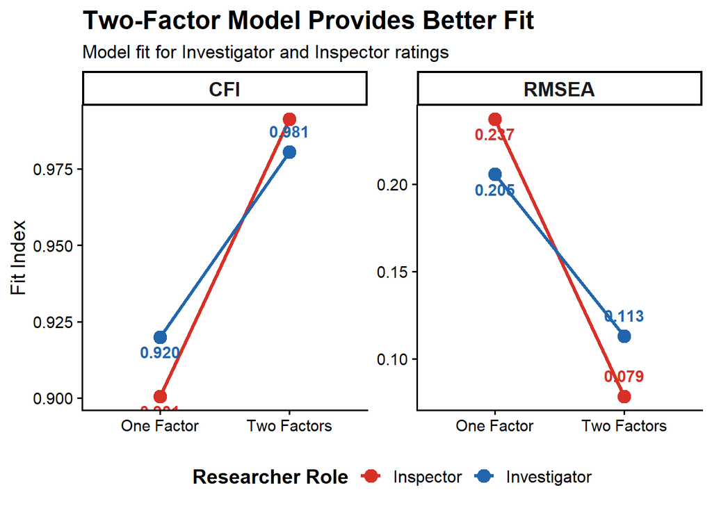

```r
# FIGURE: One-Factor vs. Two-Factor Model Fit
# Investigator vs. Inspector


library(ggplot2)
library(dplyr)
library(tidyr)

# Create model comparison data
model_comparison <- data.frame(
  Role = rep(c("Investigator", "Inspector"), each = 2),
  Model = rep(c("One Factor", "Two Factors"), 2),

  CFI = c(
    fitMeasures(investigator_one, "cfi"),
    fitMeasures(investigator_two, "cfi"),
    fitMeasures(inspector_one, "cfi"),
    fitMeasures(inspector_two, "cfi")
  ),

  RMSEA = c(
    fitMeasures(investigator_one, "rmsea"),
    fitMeasures(investigator_two, "rmsea"),
    fitMeasures(inspector_one, "rmsea"),
    fitMeasures(inspector_two, "rmsea")
  )
)

# Set order
model_comparison$Model <- factor(
  model_comparison$Model,
  levels = c("One Factor", "Two Factors")
)

# Convert to long format
plot_data <- model_comparison %>%
  pivot_longer(
    cols = c(CFI, RMSEA),
    names_to = "Fit_Index",
    values_to = "Value"
  )

# Plot

ggplot(
  plot_data,
  aes(
    x = Model,
    y = Value,
    group = Role,
    color = Role
  )
) +

  # Lines
  geom_line(linewidth = 1.2) +

  # Points
  geom_point(size = 4) +

  # Value labels
  geom_text(
    aes(
      label = sprintf("%.3f", Value),
      vjust = ifelse(
        Model == "One Factor",
        1.7,
        -1.2
      )
    ),
    size = 4,
    fontface = "bold",
    show.legend = FALSE
  ) +

  # Separate panels for CFI and RMSEA
  facet_wrap(
    ~ Fit_Index,
    scales = "free_y"
  ) +

  # Labels
  labs(
    title = "Two-Factor Model Provides Better Fit",
    subtitle = "Model fit for Investigator and Inspector ratings",
    x = NULL,
    y = "Fit Index",
    color = "Researcher Role"
  ) +

  # Colors
  scale_color_manual(
    values = c(
      "Investigator" = "#2166AC",
      "Inspector" = "#D73027"
    )
  ) +

  # Theme
  theme_classic(base_size = 14) +

  theme(
    plot.title = element_text(
      face = "bold",
      size = 18
    ),

    plot.subtitle = element_text(
      size = 13
    ),

    strip.text = element_text(
      face = "bold",
      size = 14
    ),

    legend.position = "bottom",

    legend.title = element_text(
      face = "bold"
    ),

    legend.text = element_text(
      size = 12
    )
  )
```

```r
# Install afex if it is not already installed
if (!requireNamespace("afex", quietly = TRUE)) {
  install.packages("afex")
}

# Load package
library(afex)
```

#exploratory anovas

#INTEGRITYANOVA

```r
#Exploratory ANOVAs: Severity as categorical

# INTEGRITY ANOVA
# Role = within-subjects
# Severity = within-subjects

integrity_anova_dat = tl_dat %>%
  mutate(
    Role = factor(
      role,
      levels = c("investigator", "inspector"),
      labels = c("Investigator", "Inspector")
    ),
    Severity = factor(
      severity_num,
      levels = c(0, 1, 2),
      labels = c("Minor", "Moderate", "Major")
    ),
    Participant = factor(responseid)
  )

integrity_rm_anova = aov_ez(
  id = "Participant",
  dv = "Integrity",
  data = integrity_anova_dat,
  within = c("Role", "Severity"),
  type = 3,
  fun_aggregate = mean
)
```

[output not shown]

```r
integrity_rm_anova
```

```
## Anova Table (Type 3 tests)
##
## Response: Integrity
##          Effect           df  MSE
## 1          Role       1, 444 1.39
## 2      Severity 1.75, 777.72 0.34
## 3 Role:Severity 1.88, 836.38 0.48
##             F  ges p.value
## 1 2667.74 *** .704   <.001
## 2  278.42 *** .096   <.001
## 3  365.12 *** .175   <.001
## ---
## Signif. codes:
##   0 '***' 0.001 '**' 0.01 '*' 0.05 '+' 0.1  ' ' 1
##
## Sphericity correction method: GG
```

#LIKEABILITYANOVA

```r
# LIKEABILITY ANOVA
# Role = within-subjects
# Severity = within-subjects


like_anova_dat <- model.frame(L4) %>%
  mutate(
    Role = factor(
      role_ec,
      levels = c(-1, 1),
      labels = c("Investigator", "Inspector")
    ),
    Severity = factor(
      severity_num,
      levels = c(0, 1, 2),
      labels = c("Minor", "Moderate", "Major")
    ),
    Participant = factor(responseid)
  )

like_rm_anova <- aov_ez(
  id = "Participant",
  dv = "likeability",
  data = like_anova_dat,
  within = c("Role", "Severity"),
  type = 3,
  fun_aggregate = mean
)
like_rm_anova
```

```
## Anova Table (Type 3 tests)
##
## Response: likeability
##          Effect           df  MSE          F
## 1          Role       1, 444 1.83 646.95 ***
## 2      Severity 1.91, 846.02 0.33  78.49 ***
## 3 Role:Severity 1.94, 861.00 0.53 208.28 ***
##    ges p.value
## 1 .382   <.001
## 2 .025   <.001
## 3 .101   <.001
## ---
## Signif. codes:
##   0 '***' 0.001 '**' 0.01 '*' 0.05 '+' 0.1  ' ' 1
##
## Sphericity correction method: GG
```

#TRUENESSANOVA

```r
# TRUENESS ANOVA
# Severity = within-subjects


trueness_anova_dat <- trueness_dat %>%
  mutate(
    Severity = factor(
      severity_num,
      levels = c(0, 1, 2),
      labels = c("Minor", "Moderate", "Major")
    ),
    Participant = factor(responseid)
  )

trueness_rm_anova <- aov_ez(
  id = "Participant",
  dv = "trueness",
  data = trueness_anova_dat,
  within = "Severity",
  type = 3,
  fun_aggregate = mean
)
trueness_rm_anova
```

```
## Anova Table (Type 3 tests)
##
## Response: trueness
##     Effect           df  MSE          F  ges
## 1 Severity 1.97, 875.08 0.66 388.65 *** .317
##   p.value
## 1   <.001
## ---
## Signif. codes:
##   0 '***' 0.001 '**' 0.01 '*' 0.05 '+' 0.1  ' ' 1
##
## Sphericity correction method: GG
```

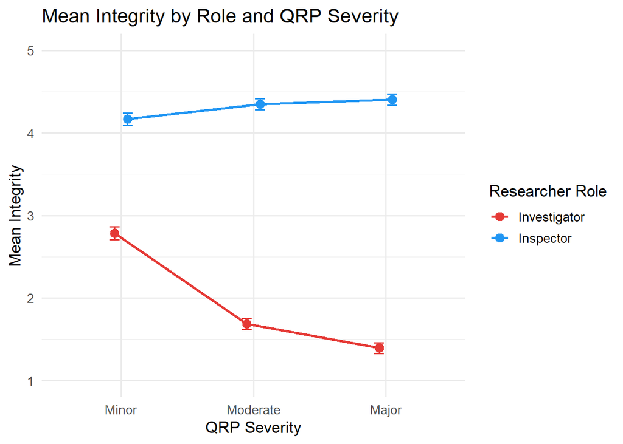

```r
### Raw means for Integrity and Likeability

plot_raw_means = function(data, outcome, outcome_label) {

  raw_df = data %>%
    group_by(role, severity_num) %>%
    summarise(
      n = sum(!is.na(.data[[outcome]])),
      mean = mean(.data[[outcome]], na.rm = TRUE),
      sd = sd(.data[[outcome]], na.rm = TRUE),
      se = sd / sqrt(n),
      lower.CL = mean - qt(0.975, df = n - 1) * se,
      upper.CL = mean + qt(0.975, df = n - 1) * se,
      .groups = "drop"
    ) %>%
    mutate(
      Severity = factor(
        severity_num,
        levels = c(0, 1, 2),
        labels = c("Minor", "Moderate", "Major")
      ),
      Role = factor(
        role,
        levels = c("investigator", "inspector"),
        labels = c("Investigator", "Inspector")
      )
    )

  ggplot(
    raw_df,
    aes(
      x = Severity,
      y = mean,
      color = Role,
      group = Role
    )
  ) +
    geom_line(linewidth = 1, position = position_dodge(width = 0.2)) +
    geom_point(size = 3, position = position_dodge(width = 0.2)) +
    geom_errorbar(
      aes(ymin = lower.CL, ymax = upper.CL),
      width = 0.15,
      position = position_dodge(width = 0.2)
    ) +
    scale_color_manual(
      values = c(
        "Investigator" = "#E53935",
        "Inspector" = "#2196F3"
      )
    ) +
    labs(
      title = paste("Mean", outcome_label, "by Role and QRP Severity"),
      y = paste("Mean", outcome_label),
      x = "QRP Severity",
      color = "Researcher Role"
    ) +
    theme_minimal(base_size = 13) +
    coord_cartesian(ylim = c(1, 5))
}

# Integrity
plot_raw_means(tl_dat, "Integrity", "Integrity")
```

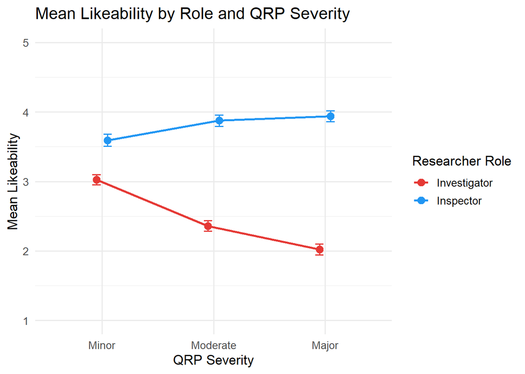

```r
# Likeability
plot_raw_means(tl_dat, "likeability", "Likeability")
```

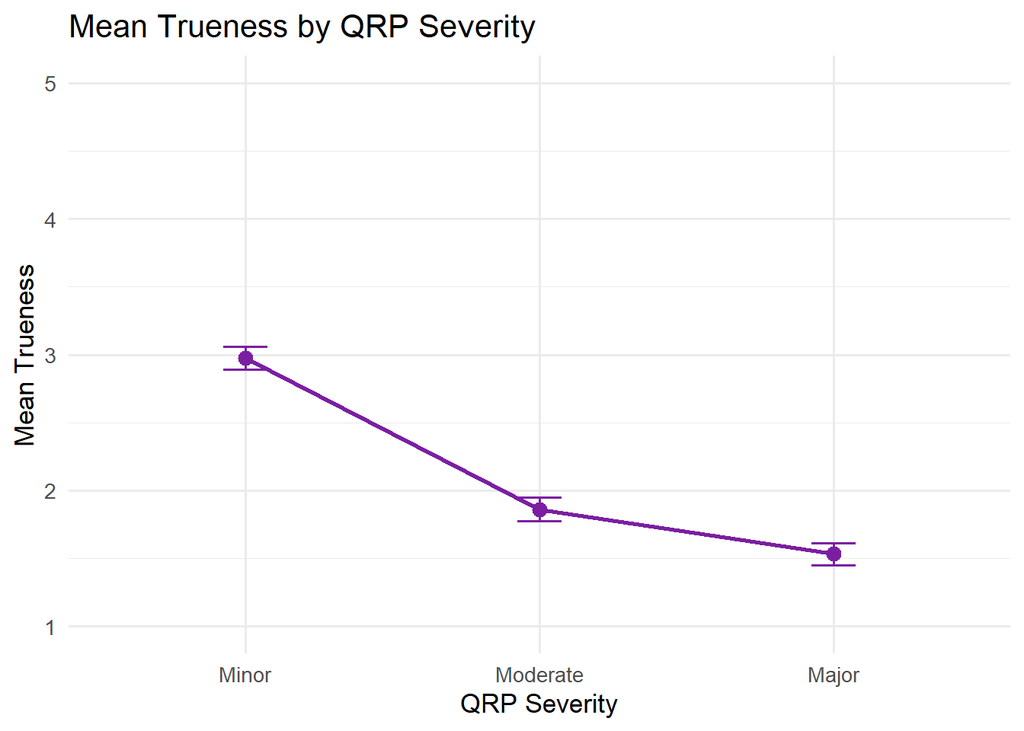

```r
### Raw means for Trueness

plot_raw_trueness = function(data) {

  raw_df = data %>%
    group_by(severity_num) %>%
    summarise(
      n = sum(!is.na(trueness)),
      mean = mean(trueness, na.rm = TRUE),
      sd = sd(trueness, na.rm = TRUE),
      se = sd / sqrt(n),
      lower.CL = mean - qt(0.975, df = n - 1) * se,
      upper.CL = mean + qt(0.975, df = n - 1) * se,
      .groups = "drop"
    ) %>%
    mutate(
      Severity = factor(
        severity_num,
        levels = c(0, 1, 2),
        labels = c("Minor", "Moderate", "Major")
      )
    )

  ggplot(
    raw_df,
    aes(
      x = Severity,
      y = mean,
      group = 1
    )
  ) +
    geom_line(linewidth = 1, color = "#7B1FA2") +
    geom_point(size = 3, color = "#7B1FA2") +
    geom_errorbar(
      aes(ymin = lower.CL, ymax = upper.CL),
      width = 0.15,
      color = "#7B1FA2"
    ) +
    labs(
      title = "Mean Trueness by QRP Severity",
      y = "Mean Trueness",
      x = "QRP Severity"
    ) +
    theme_minimal(base_size = 13) +
    coord_cartesian(ylim = c(1, 5))
}

plot_raw_trueness(trueness_dat)
```